# CERF data workup

Kim Cressman

2017-11-05

Load packages

```r
library(tidyverse)
library(reshape2)
library(lubridate)
library(htmlTable)
library(shape)
library(RColorBrewer)
library(knitr)
```

### Data Download

**NERRS data**: I used the “Custom Query” option from the CDMO’s Advanced Query System (http://cdmo.baruch.sc.edu/aqs/) to download WQ and MET data from all stations at all 5 Gulf of Mexico Reserves, from 5/1/2017 - 10/30/2017. This was delivered in one CSV file, which I named “nerrs.csv”.

**IOOS data**: I used the GCOOS data portal to find stations that had water level and/or salinity data in gaps between NERRS. I ended up downloading data from two NOAA Tides and Currents stations; one in Texas, near Houston (NOS 8770613), and one in Louisiana (NOS 8764314). It was surprisingly difficult to find the data; there was no direct link that I could find from the GCOOS portal. I did get enough information to google the stations and find them. Data through Tides and Currents can only be downloaded a month at a time, and there are three separate data types to deal with, so I figured out the url pattern for each type (MET, water level, and temp/conductivity), copied and pasted, changed the dates, changed the stations, and downloaded everything in one run of the script `Data downloads`. I then used the script `Data concatination` to glue all of those NOS files together, and exported a CSV that I named “NOS_all.csv”.

### Load data

Also, combine NOS files with NERRS files.

Okay, there are 40 variables in my NERRS files, so I’m going to reduce that by removing rejected data and data outside sensor limits (QC codes -3, -4, and -5), then getting rid of the QC columns.

```r
nerrs_init <- read.csv("nerrs.csv", stringsAsFactors = FALSE)
####
names(nerrs_init) <- tolower(names(nerrs_init))

# remove rejected nerrs data
nerrs_init$temp[grepl("-3|-4|-5", nerrs_init$f_temp) == TRUE] <- NA
nerrs_init$spcond[grepl("-3|-4|-5", nerrs_init$f_spcond) == TRUE] <- NA
nerrs_init$sal[grepl("-3|-4|-5", nerrs_init$f_sal) == TRUE] <- NA
nerrs_init$depth[grepl("-3|-4|-5", nerrs_init$f_depth) == TRUE] <- NA
nerrs_init$level[grepl("-3|-4|-5", nerrs_init$f_level) == TRUE] <- NA
nerrs_init$bp[grepl("-3|-4|-5", nerrs_init$f_bp) == TRUE] <- NA
nerrs_init$rh[grepl("-3|-4|-5", nerrs_init$f_rh) == TRUE] <- NA
nerrs_init$wspd[grepl("-3|-4|-5", nerrs_init$f_wspd) == TRUE] <- NA
nerrs_init$maxwspd[grepl("-3|-4|-5", nerrs_init$f_maxwspd) == TRUE] <- NA
nerrs_init$wdir[grepl("-3|-4|-5", nerrs_init$f_wdir) == TRUE] <- NA
nerrs_init$atemp[grepl("-3|-4|-5", nerrs_init$f_atemp) == TRUE] <- NA
```

```r
nerrs <- nerrs_init %>%
    mutate(datetimestamp = mdy_hm(datetimestamp),
           wdir = as.numeric(wdir),
           rh = as.numeric(rh),
           bp = as.numeric(bp)) %>%
    select(datetimestamp,
           stationcode,
           atemp,
           rh,
           bp,
           wspd,
           maxwspd,
           wdir,
           totprcp,
           spcond,
           sal,
           depth,
           level,
           turb)

nos <- read.csv("NOS_all.csv") %>%
    mutate(datetimestamp = ymd_hms(datetimestamp))

dat <- bind_rows(nerrs, nos) %>%
    mutate(site = substr(stationcode, 1, 3),
           stationcode = sub("\\s+$", "", stationcode)) %>%
    group_by(stationcode)
```

## split up into WQ and MET

```r
wq <- c("apadbwq", "apapcwq", "gndbcwq", "gndblwq", "la_nos", "rkbfuwq", "rkbmbwq", "tx_nos", "wkbfrwq", "wkbwbwq", "marmbwq")
met <- c("apaebmet", "gndcrmet", "la_nos", "rkbuhmet", "tx_nos", "wkbshmet", "marcemet", "marscmet")

dat_wq <- dat %>%
    filter(stationcode %in% wq) %>%
    select(datetimestamp, stationcode, sal, depth, level, temp, spcond)

dat_met <- dat %>%
    filter(stationcode %in% met) %>%
    select(datetimestamp, stationcode, atemp, rh, bp, wspd, maxwspd, wdir, totprcp)

## rkb's wind sensor is screwy; replace those values with NAs
dat_met$wspd[dat_met$stationcode == "rkbuhmet"] <- NA
dat_met$maxwspd[dat_met$stationcode == "rkbuhmet"] <- NA
```

## Some initial graphs to see what’s interesting across the gulf

**Baro Pressure** - always a good storm indicator

Ohhhhh noooooo, everything is in LST; need to put it all into EST or something so time scale is the same.

Landfall dates: These will be vertical lines on the graphs.

- 6-22 - TS Cindy
- 7-31 - TS Emily
- 8-26 - MH Harvey
- 9-10 - MH Irma
- 10-8 - H Nate

```r
Cindy <- as.numeric(as.POSIXct("2017-06-22 12:00"))
Emily <- as.numeric(as.POSIXct("2017-07-31 12:00"))
Harvey <- as.numeric(as.POSIXct("2017-08-26 12:00"))
Irma <- as.numeric(as.POSIXct("2017-09-10 12:00"))
Nate <- as.numeric(as.POSIXct("2017-10-08 12:00"))
```

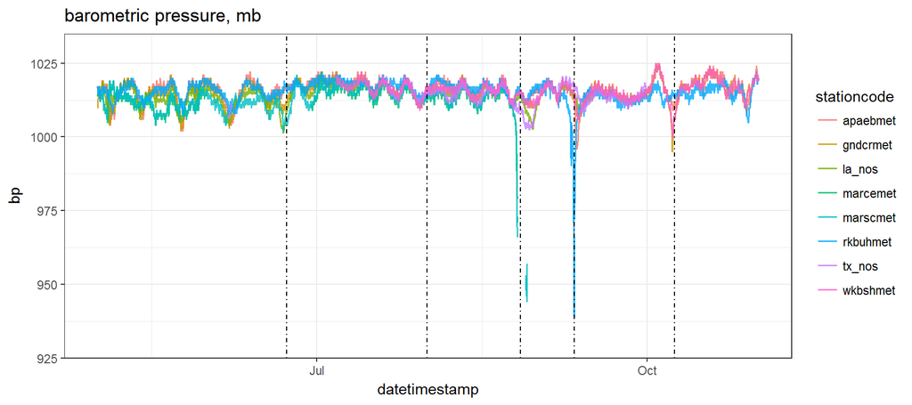

```r
ggplot(dat_met, aes(x=datetimestamp, y=bp)) +
    geom_line(aes(col=stationcode), lwd=0.7, alpha=0.8) +
    geom_vline(aes(xintercept=Cindy), lty=4, lwd=0.5) +
    geom_vline(aes(xintercept=Emily), lty=4, lwd=0.5) +
    geom_vline(aes(xintercept=Harvey), lty=4, lwd=0.5) +
    geom_vline(aes(xintercept=Irma), lty=4, lwd=0.5) +
    geom_vline(aes(xintercept=Nate), lty=4, lwd=0.5) +
    coord_cartesian(ylim=c(930, 1030)) +
    ggtitle("barometric pressure, mb") +
    theme_bw()
```

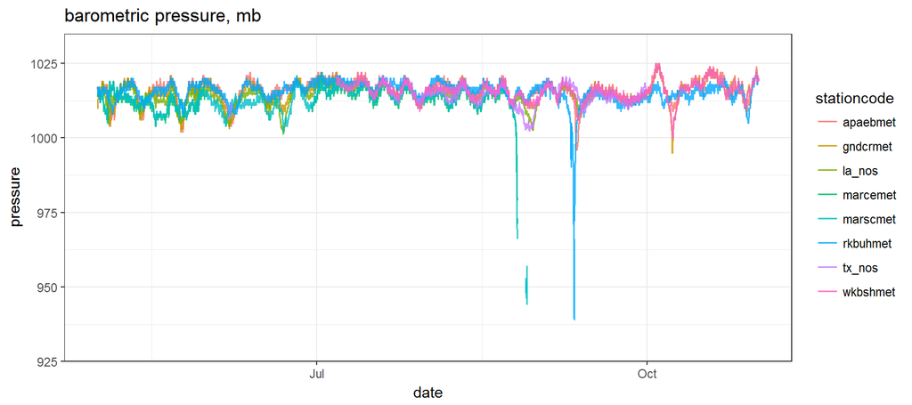

```r
ggplot(dat_met, aes(x=datetimestamp, y=bp)) +
    geom_line(aes(col=stationcode), lwd=0.7, alpha=0.8) +
    coord_cartesian(ylim=c(930, 1030)) +
    ggtitle("barometric pressure, mb") +
    xlab("date") +
    ylab("pressure") +
    theme_bw()
```

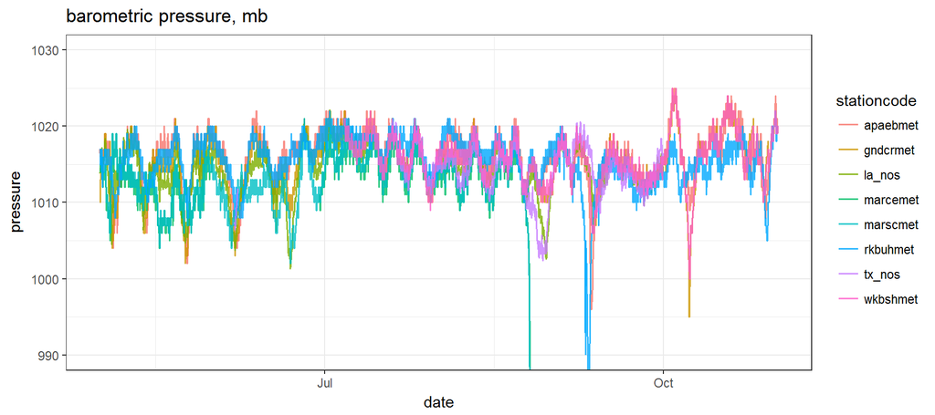

```r
ggplot(dat_met, aes(x=datetimestamp, y=bp)) +
    geom_line(aes(col=stationcode), lwd=0.7, alpha=0.8) +
    coord_cartesian(ylim=c(990, 1030)) +
    ggtitle("barometric pressure, mb") +
    xlab("date") +
    ylab("pressure") +
    theme_bw()
```

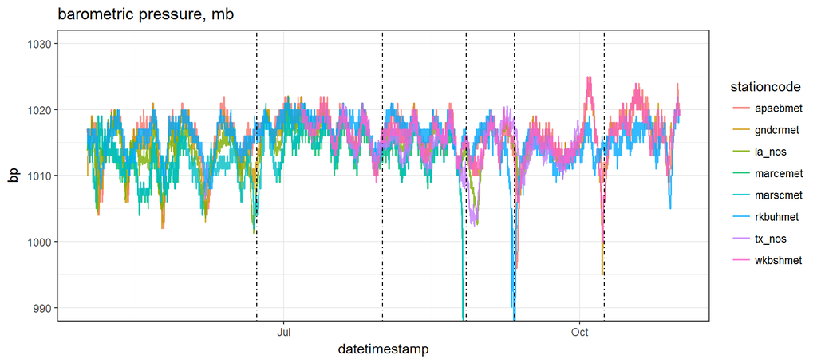

```r
ggplot(dat_met, aes(x=datetimestamp, y=bp)) +
    geom_line(aes(col=stationcode), lwd=0.7, alpha=0.8) +
    geom_vline(aes(xintercept=Cindy), lty=4, lwd=0.5) +
    geom_vline(aes(xintercept=Emily), lty=4, lwd=0.5) +
    geom_vline(aes(xintercept=Harvey), lty=4, lwd=0.5) +
    geom_vline(aes(xintercept=Irma), lty=4, lwd=0.5) +
    geom_vline(aes(xintercept=Nate), lty=4, lwd=0.5) +
    coord_cartesian(ylim=c(990, 1030)) +
    ggtitle("barometric pressure, mb") +
    theme_bw()
```

```r
# ggplot(dat_met, aes(x=datetimestamp, y=bp, col=stationcode)) +
#     geom_smooth(method="loess", se=FALSE, span=0.05, lwd=0.5, alpha=0.6) +
#     coord_cartesian(ylim=c(930, 1030)) +
#     theme_bw()
#
# ggplot(dat_met, aes(x=datetimestamp, y=bp, col=stationcode)) +
#     geom_smooth(method="loess", se=FALSE, span=0.01, lwd=0.5, alpha=0.6) +
#     coord_cartesian(ylim=c(930, 1030)) +
#     theme_bw()
#
# ggplot(dat_met, aes(x=datetimestamp, y=bp, col=stationcode)) +
#     geom_smooth(method="loess", se=FALSE, span=0.05) +
#     theme_bw()
```

**wind speed**

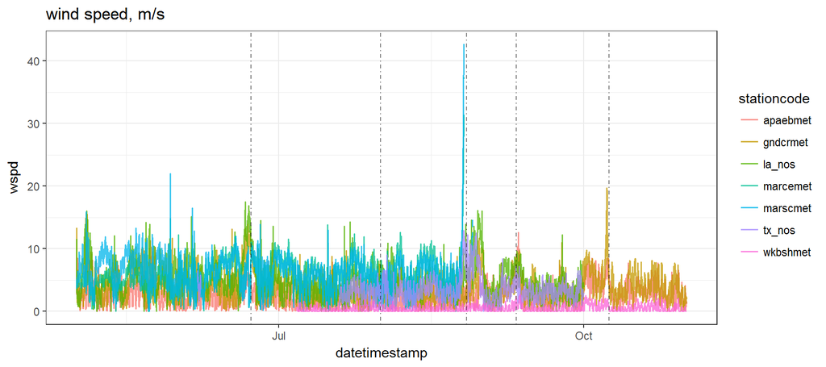

```r
dat_met2 <- filter(dat_met, stationcode != "rkbuhmet")
ggplot(dat_met2, aes(x=datetimestamp, y=wspd)) +
    geom_line(aes(col=stationcode), lwd=0.7, alpha=0.75) +
    geom_vline(aes(xintercept=Cindy), lty=4, lwd=0.5, alpha=0.5) +
    geom_vline(aes(xintercept=Emily), lty=4, lwd=0.5, alpha=0.5) +
    geom_vline(aes(xintercept=Harvey), lty=4, lwd=0.5, alpha=0.5) +
    geom_vline(aes(xintercept=Irma), lty=4, lwd=0.5, alpha=0.5) +
    geom_vline(aes(xintercept=Nate), lty=4, lwd=0.5, alpha=0.5) +
    ggtitle("wind speed, m/s") +
    theme_bw()
```

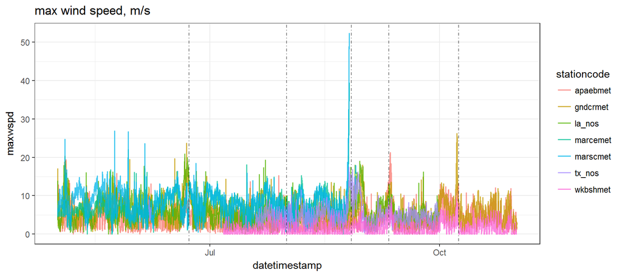

```r
ggplot(dat_met2, aes(x=datetimestamp, y=maxwspd)) +
    geom_line(aes(col=stationcode), lwd=0.7, alpha=0.75) +
    geom_vline(aes(xintercept=Cindy), lty=4, lwd=0.5, alpha=0.5) +
    geom_vline(aes(xintercept=Emily), lty=4, lwd=0.5, alpha=0.5) +
    geom_vline(aes(xintercept=Harvey), lty=4, lwd=0.5, alpha=0.5) +
    geom_vline(aes(xintercept=Irma), lty=4, lwd=0.5, alpha=0.5) +
    geom_vline(aes(xintercept=Nate), lty=4, lwd=0.5, alpha=0.5) +
    ggtitle("max wind speed, m/s") +
    theme_bw()
```

**depth/level**

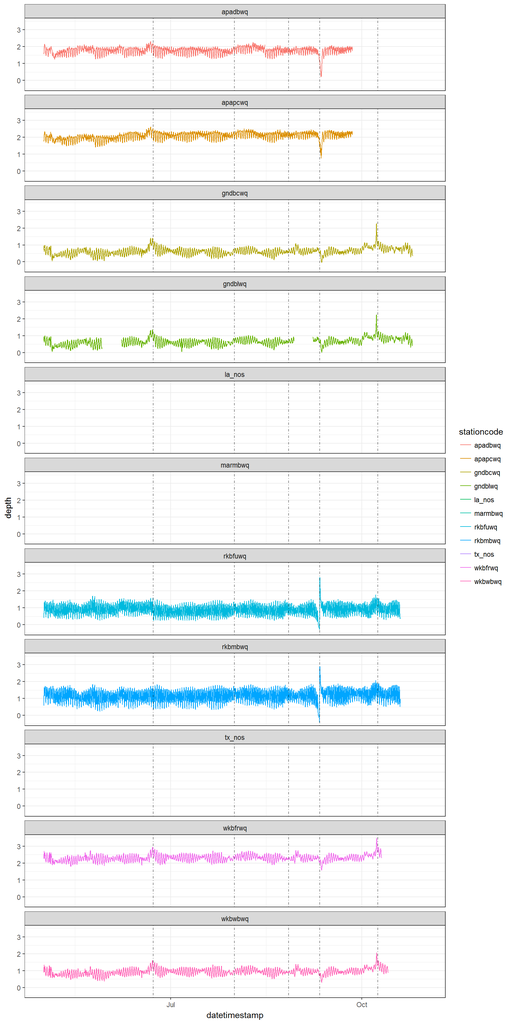

```r
ggplot(dat_wq, aes(x=datetimestamp, y=depth)) +
    geom_line(aes(col=stationcode), lwd=0.5) +
    geom_vline(aes(xintercept=Cindy), lty=4, lwd=0.5, alpha=0.5) +
    geom_vline(aes(xintercept=Emily), lty=4, lwd=0.5, alpha=0.5) +
    geom_vline(aes(xintercept=Harvey), lty=4, lwd=0.5, alpha=0.5) +
    geom_vline(aes(xintercept=Irma), lty=4, lwd=0.5, alpha=0.5) +
    geom_vline(aes(xintercept=Nate), lty=4, lwd=0.5, alpha=0.5) +
    facet_wrap(~stationcode, ncol=1) +
    theme_bw()
```

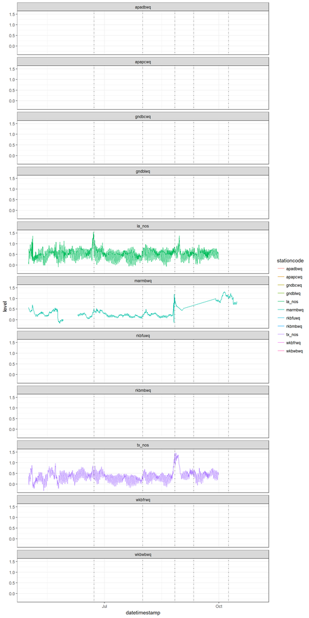

```r
ggplot(dat_wq, aes(x=datetimestamp, y=level)) +
    geom_line(aes(col=stationcode), lwd=0.5) +
    geom_vline(aes(xintercept=Cindy), lty=4, lwd=0.5, alpha=0.5) +
    geom_vline(aes(xintercept=Emily), lty=4, lwd=0.5, alpha=0.5) +
    geom_vline(aes(xintercept=Harvey), lty=4, lwd=0.5, alpha=0.5) +
    geom_vline(aes(xintercept=Irma), lty=4, lwd=0.5, alpha=0.5) +
    geom_vline(aes(xintercept=Nate), lty=4, lwd=0.5, alpha=0.5) +
    facet_wrap(~stationcode, ncol=1) +
    theme_bw()
```

**spc/conductivity**

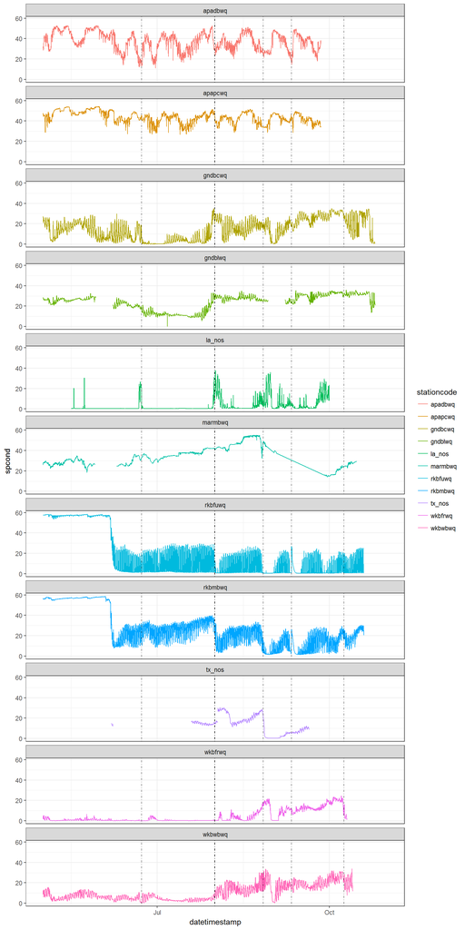

```r
ggplot(dat_wq, aes(x=datetimestamp, y=spcond)) +
    geom_line(aes(col=stationcode), lwd=0.5) +
    geom_vline(aes(xintercept=Cindy), lty=4, lwd=0.5, alpha=0.5) +
    geom_vline(aes(xintercept=Emily), lty=4, lwd=0.5) +
    geom_vline(aes(xintercept=Harvey), lty=4, lwd=0.5, alpha=0.5) +
    geom_vline(aes(xintercept=Irma), lty=4, lwd=0.5, alpha=0.5) +
    geom_vline(aes(xintercept=Nate), lty=4, lwd=0.5, alpha=0.5) +
    facet_wrap(~stationcode, ncol=1) +
    theme_bw()
```

### Data summaries

Part of this project is meant to summarize data. I’ll be pulling code from Kari St. Laurent and Shannon Dunnigan below. I’ll use dates from the National Hurricane Center to define storm periods; for baseline I’ll go 2 weeks before the start date; and for post-storm period I’ll go two weeks after the end date. I originally used 30 days after storm end date, but then I had post-storm periods that were affected by the next hurricane. So these may not be the best but they’re a starting point and can be tinkered with later.

I’m going to want to pull out min, max, mean, and median of various paramaters at each station - both from the 15-minute (or hourly) data, and from daily averages. So I’m probably going to need to make a function or two to streamline this.

First, I’ve made a data frame of the storms and their start and end dates:

```r
# make a data frame of the storms to look at

storm_info <- data.frame(storm_name = c("Cindy", "Emily", "Harvey", "Irma", "Nate"),
                         storm_start = c("2017-06-20", "2017-07-31", "2017-08-17", "2017-08-30", "2017-10-04"),
                         storm_end = c("2017-06-23", "2017-08-01", "2017-08-31", "2017-09-12", "2017-10-09"))

storm_info <- storm_info %>%
    mutate(storm_start = ymd(storm_start),
           storm_end = ymd(storm_end),
           baseline_start = storm_start - days(14),
           post_end = storm_end + days(14)) %>%
    select(storm_name, baseline_start, storm_start, storm_end, post_end)

kable(storm_info)
```

| storm_name | baseline_start | storm_start | storm_end | post_end |
| --- | --- | --- | --- | --- |
| Cindy | 2017-06-06 | 2017-06-20 | 2017-06-23 | 2017-07-07 |
| Emily | 2017-07-17 | 2017-07-31 | 2017-08-01 | 2017-08-15 |
| Harvey | 2017-08-03 | 2017-08-17 | 2017-08-31 | 2017-09-14 |
| Irma | 2017-08-16 | 2017-08-30 | 2017-09-12 | 2017-09-26 |
| Nate | 2017-09-20 | 2017-10-04 | 2017-10-09 | 2017-10-23 |

Would be nice to include some of the other parameters that Shannon looked up, like max wind speed, min baro pressure, amount of damages, etc. That’s lower priority at this moment though.

Because of the potential for date overlap between some post-storm periods and the next pre-storm periods, I set up a routine to summarize data for each storm individually and then combine all of it together again.

**Create the functions**

```r
# first, pull from the storm_info data frame the storm of interest; start date for subsetting; end date for subsetting; and storm start and end dates.
# storm_of_interest <- "Cindy"

wq_summaries <- function(storm_of_interest){

    subset_start <- storm_info$baseline_start[storm_info$storm_name == storm_of_interest]
    subset_end <- storm_info$post_end[storm_info$storm_name == storm_of_interest]
    soi_start <- storm_info$storm_start[storm_info$storm_name == storm_of_interest]
    soi_end <- storm_info$storm_end[storm_info$storm_name == storm_of_interest]


    ### WQ
    # subset data for this storm; add a column for baseline, post-storm, or during storm
    soi_dat <- dat_wq %>%
        filter(datetimestamp >= subset_start,
               datetimestamp <= subset_end) %>%
        mutate(storm_name = storm_of_interest)
    soi_dat$period <- ifelse(soi_dat$datetimestamp < soi_start, "pre",
                             ifelse(soi_dat$datetimestamp > soi_end, "post",
                                    "storm"))

    # use dplyr to group by station and time period, then generate summaries
    # round means and medians to 2 or 3 digits past the decimal point, depending on parameter
    summary_wq <- soi_dat %>%
        group_by(stationcode, period) %>%
        summarize(depth_min = min(depth, na.rm=TRUE),
                  depth_mean = round(mean(depth, na.rm=TRUE), 3),
                  depth_median = round(median(depth, na.rm=TRUE), 3),
                  depth_max = max(depth, na.rm=TRUE),
                  level_min = min(level, na.rm=TRUE),
                  level_mean = round(mean(level, na.rm=TRUE), 3),
                  level_median = round(median(level, na.rm=TRUE), 3),
                  level_max = max(level, na.rm=TRUE),
                  spcond_min = min(spcond, na.rm=TRUE),
                  spcond_mean = round(mean(spcond, na.rm=TRUE), 2),
                  spcond_median = round(median(spcond, na.rm=TRUE), 2),
                  spcond_max = max(spcond, na.rm=TRUE),
                  sal_min = min(sal, na.rm=TRUE),
                  sal_mean = round(mean(sal, na.rm=TRUE), 2),
                  sal_median = round(median(sal, na.rm=TRUE), 2),
                  sal_max = max(sal, na.rm=TRUE)) %>%
        mutate(storm_name = storm_of_interest)

}



met_summaries <- function(storm_of_interest) {

    subset_start <- storm_info$baseline_start[storm_info$storm_name == storm_of_interest]
    subset_end <- storm_info$post_end[storm_info$storm_name == storm_of_interest]
    soi_start <- storm_info$storm_start[storm_info$storm_name == storm_of_interest]
    soi_end <- storm_info$storm_end[storm_info$storm_name == storm_of_interest]


    ### MET
    # subset data for this storm; add a column for baseline, post-storm, or during storm
    soi_dat <- dat_met %>%
        filter(datetimestamp >= subset_start,
               datetimestamp <= subset_end) %>%
        mutate(storm_name = storm_of_interest)
    soi_dat$period <- ifelse(soi_dat$datetimestamp < soi_start, "pre",
                             ifelse(soi_dat$datetimestamp > soi_end, "post",
                                    "storm"))

    # use dplyr to group by station and time period, then generate summaries
    # round means and medians to 2 or 3 digits past the decimal point, depending on parameter
    summary_met <- soi_dat %>%
        group_by(stationcode, period) %>%
        summarize(bp_min = min(bp, na.rm=TRUE),
                  bp_mean = round(mean(bp, na.rm=TRUE), 2),
                  bp_median = round(median(bp, na.rm=TRUE), 2),
                  bp_max = max(bp, na.rm=TRUE),
                  wspd_min = min(wspd, na.rm=TRUE),
                  wspd_mean = round(mean(wspd, na.rm=TRUE), 2),
                  wspd_median = round(median(wspd, na.rm=TRUE), 2),
                  wspd_max = max(wspd, na.rm=TRUE),
                  maxwspd_min = min(maxwspd, na.rm=TRUE),
                  maxwspd_mean = round(mean(maxwspd, na.rm=TRUE), 2),
                  maxwspd_median = round(median(maxwspd, na.rm=TRUE), 2),
                  maxwspd_max = max(maxwspd, na.rm=TRUE)) %>%
        mutate(storm_name = storm_of_interest)

}
```

**Run the functions**

#### Cindy

```r
wq_Cindy <- wq_summaries("Cindy")
met_Cindy <- met_summaries("Cindy")
kable(wq_Cindy, caption = "Water Quality parameter summaries from Cindy")
```

Water Quality parameter summaries from Cindy

| stationcode | period | depth_min | depth_mean | depth_median | depth_max | level_min | level_mean | level_median | level_max | spcond_min | spcond_mean | spcond_median | spcond_max | sal_min | sal_mean | sal_median | sal_max | storm_name |
| --- | --- | --- | --- | --- | --- | --- | --- | --- | --- | --- | --- | --- | --- | --- | --- | --- | --- | --- |
| apadbwq | post | 1.29 | 1.760 | 1.800 | 2.09 | Inf | NaN | NA | -Inf | 11.10 | 34.38 | 36.90 | 47.53 | 6.3 | 21.60 | 23.20 | 30.8 | Cindy |
| apadbwq | pre | 1.33 | 1.777 | 1.820 | 2.18 | Inf | NaN | NA | -Inf | 13.90 | 34.71 | 35.41 | 49.45 | 8.0 | 21.86 | 22.30 | 32.3 | Cindy |
| apadbwq | storm | 1.46 | 1.996 | 2.070 | 2.31 | Inf | NaN | NA | -Inf | 12.02 | 19.33 | 18.37 | 33.64 | 6.8 | 11.50 | 10.80 | 21.0 | Cindy |
| apapcwq | post | 1.67 | 2.115 | 2.160 | 2.44 | Inf | NaN | NA | -Inf | 26.96 | 40.81 | 41.86 | 49.76 | 16.5 | 26.02 | 26.70 | 32.4 | Cindy |
| apapcwq | pre | 1.68 | 2.101 | 2.130 | 2.48 | Inf | NaN | NA | -Inf | 27.24 | 43.27 | 42.31 | 51.47 | 16.7 | 27.83 | 27.10 | 33.7 | Cindy |
| apapcwq | storm | 1.80 | 2.313 | 2.390 | 2.63 | Inf | NaN | NA | -Inf | 40.74 | 43.30 | 43.21 | 48.03 | 26.0 | 27.82 | 27.80 | 31.2 | Cindy |
| gndbcwq | post | 0.26 | 0.669 | 0.665 | 1.22 | Inf | NaN | NA | -Inf | 0.06 | 0.65 | 0.29 | 9.94 | 0.0 | 0.33 | 0.10 | 5.6 | Cindy |
| gndbcwq | pre | 0.26 | 0.602 | 0.610 | 0.95 | Inf | NaN | NA | -Inf | 0.83 | 9.20 | 7.71 | 29.75 | 0.4 | 5.25 | 4.20 | 18.4 | Cindy |
| gndbcwq | storm | 0.62 | 1.022 | 1.010 | 1.42 | Inf | NaN | NA | -Inf | 0.36 | 12.78 | 14.66 | 22.62 | 0.2 | 7.46 | 8.50 | 13.6 | Cindy |
| gndblwq | post | 0.04 | 0.604 | 0.600 | 1.12 | Inf | NaN | NA | -Inf | 0.03 | 13.03 | 12.64 | 21.29 | 0.0 | 7.45 | 7.20 | 12.7 | Cindy |
| gndblwq | pre | 0.28 | 0.617 | 0.605 | 0.97 | Inf | NaN | NA | -Inf | 17.16 | 21.73 | 21.14 | 28.62 | 10.1 | 13.01 | 12.60 | 17.6 | Cindy |
| gndblwq | storm | 0.63 | 0.982 | 0.970 | 1.36 | Inf | NaN | NA | -Inf | 13.67 | 19.07 | 19.53 | 22.41 | 7.9 | 11.31 | 11.60 | 13.5 | Cindy |
| la_nos | post | Inf | NaN | NA | -Inf | 0.013 | 0.535 | 0.540 | 1.153 | 0.39 | 0.45 | 0.42 | 2.77 | Inf | NaN | NA | -Inf | Cindy |
| la_nos | pre | Inf | NaN | NA | -Inf | 0.095 | 0.556 | 0.570 | 0.900 | 0.31 | 0.35 | 0.35 | 0.58 | Inf | NaN | NA | -Inf | Cindy |
| la_nos | storm | Inf | NaN | NA | -Inf | 0.188 | 0.847 | 0.810 | 1.551 | 0.36 | 9.34 | 3.17 | 26.88 | Inf | NaN | NA | -Inf | Cindy |
| marmbwq | post | Inf | NaN | NA | -Inf | 0.110 | 0.312 | 0.330 | 0.550 | 27.15 | 32.39 | 32.50 | 37.18 | 16.6 | 20.12 | 20.20 | 23.4 | Cindy |
| marmbwq | pre | Inf | NaN | NA | -Inf | 0.040 | 0.201 | 0.220 | 0.330 | 24.49 | 27.73 | 26.22 | 36.45 | 14.8 | 16.99 | 15.90 | 22.9 | Cindy |
| marmbwq | storm | Inf | NaN | NA | -Inf | 0.120 | 0.289 | 0.320 | 0.520 | 30.15 | 33.34 | 33.83 | 35.28 | 18.6 | 20.76 | 21.10 | 22.1 | Cindy |
| rkbfuwq | post | 0.25 | 0.783 | 0.780 | 1.48 | Inf | NaN | NA | -Inf | 1.23 | 8.63 | 3.00 | 27.89 | 0.6 | 4.98 | 1.55 | 17.0 | Cindy |
| rkbfuwq | pre | 0.46 | 1.025 | 1.030 | 1.56 | Inf | NaN | NA | -Inf | 0.97 | 11.41 | 5.15 | 55.05 | 0.5 | 6.81 | 2.80 | 36.4 | Cindy |
| rkbfuwq | storm | 0.24 | 0.988 | 0.990 | 1.59 | Inf | NaN | NA | -Inf | 1.06 | 5.76 | 1.58 | 20.39 | 0.5 | 3.24 | 0.80 | 12.1 | Cindy |
| rkbmbwq | post | 0.37 | 1.101 | 1.110 | 1.83 | Inf | NaN | NA | -Inf | 8.25 | 23.97 | 25.88 | 35.32 | 4.6 | 14.51 | 15.70 | 22.1 | Cindy |
| rkbmbwq | pre | 0.38 | 1.128 | 1.140 | 1.72 | Inf | NaN | NA | -Inf | 7.86 | 18.88 | 18.17 | 53.09 | 4.3 | 11.29 | 10.70 | 35.0 | Cindy |
| rkbmbwq | storm | 0.35 | 1.134 | 1.140 | 1.75 | Inf | NaN | NA | -Inf | 8.23 | 22.69 | 25.10 | 32.37 | 4.6 | 13.69 | 15.20 | 20.1 | Cindy |
| tx_nos | post | Inf | NaN | NA | -Inf | -0.012 | 0.396 | 0.394 | 0.853 | Inf | NaN | NA | -Inf | Inf | NaN | NA | -Inf | Cindy |
| tx_nos | pre | Inf | NaN | NA | -Inf | -0.060 | 0.411 | 0.399 | 0.799 | 12.05 | 13.38 | 13.26 | 15.10 | Inf | NaN | NA | -Inf | Cindy |
| tx_nos | storm | Inf | NaN | NA | -Inf | 0.168 | 0.516 | 0.508 | 0.857 | Inf | NaN | NA | -Inf | Inf | NaN | NA | -Inf | Cindy |
| wkbfrwq | post | 1.89 | 2.326 | 2.325 | 2.84 | Inf | NaN | NA | -Inf | 0.06 | 1.12 | 0.26 | 5.55 | 0.0 | 0.59 | 0.10 | 3.0 | Cindy |
| wkbfrwq | pre | 1.87 | 2.258 | 2.250 | 2.60 | Inf | NaN | NA | -Inf | 0.06 | 0.30 | 0.16 | 2.35 | 0.0 | 0.16 | 0.10 | 1.2 | Cindy |
| wkbfrwq | storm | 2.05 | 2.505 | 2.490 | 2.95 | Inf | NaN | NA | -Inf | 0.06 | 0.20 | 0.12 | 1.35 | 0.0 | 0.09 | 0.10 | 0.7 | Cindy |
| wkbwbwq | post | 0.58 | 0.973 | 0.970 | 1.50 | Inf | NaN | NA | -Inf | 0.25 | 5.31 | 4.89 | 10.57 | 0.1 | 2.87 | 2.60 | 6.0 | Cindy |
| wkbwbwq | pre | 0.58 | 0.920 | 0.920 | 1.26 | Inf | NaN | NA | -Inf | 0.94 | 4.84 | 4.47 | 8.66 | 0.5 | 2.60 | 2.40 | 4.8 | Cindy |
| wkbwbwq | storm | 0.75 | 1.176 | 1.160 | 1.61 | Inf | NaN | NA | -Inf | 0.26 | 4.10 | 3.84 | 10.93 | 0.1 | 2.23 | 2.00 | 6.2 | Cindy |

```r
kable(met_Cindy, caption = "Weather parameter summaries from Cindy")
```

Weather parameter summaries from Cindy

| stationcode | period | bp_min | bp_mean | bp_median | bp_max | wspd_min | wspd_mean | wspd_median | wspd_max | maxwspd_min | maxwspd_mean | maxwspd_median | maxwspd_max | storm_name |
| --- | --- | --- | --- | --- | --- | --- | --- | --- | --- | --- | --- | --- | --- | --- |
| apaebmet | post | 1015.0 | 1018.77 | 1019.0 | 1022.0 | 0.0 | 2.26 | 1.8 | 8.0 | 0.2 | 3.44 | 2.9 | 10.7 | Cindy |
| apaebmet | pre | 1004.0 | 1014.43 | 1015.0 | 1022.0 | 0.0 | 2.37 | 2.1 | 6.7 | 0.2 | 3.67 | 3.4 | 13.1 | Cindy |
| apaebmet | storm | 1013.0 | 1015.99 | 1016.0 | 1018.0 | 1.1 | 4.35 | 4.7 | 7.2 | 1.8 | 6.50 | 6.8 | 11.5 | Cindy |
| gndcrmet | post | 1013.0 | 1017.93 | 1018.0 | 1022.0 | 0.3 | 3.76 | 3.7 | 9.8 | 1.0 | 5.12 | 5.2 | 15.1 | Cindy |
| gndcrmet | pre | 1003.0 | 1013.43 | 1014.0 | 1020.0 | 0.2 | 4.01 | 3.8 | 13.1 | 0.7 | 5.34 | 5.1 | 19.7 | Cindy |
| gndcrmet | storm | 1008.0 | 1011.49 | 1011.0 | 1016.0 | 5.3 | 9.92 | 10.3 | 13.9 | 7.3 | 12.81 | 12.9 | 23.7 | Cindy |
| la_nos | post | 1010.1 | 1017.04 | 1017.3 | 1022.1 | 0.6 | 4.96 | 4.7 | 14.5 | 1.1 | 5.90 | 5.5 | 16.4 | Cindy |
| la_nos | pre | 1003.7 | 1012.61 | 1013.2 | 1017.4 | 0.1 | 5.08 | 5.0 | 12.7 | 0.8 | 5.93 | 5.8 | 16.3 | Cindy |
| la_nos | storm | 1001.3 | 1006.49 | 1006.8 | 1011.7 | 6.4 | 12.11 | 12.2 | 17.5 | 7.0 | 14.43 | 14.7 | 20.9 | Cindy |
| marcemet | post | 1009.0 | 1015.07 | 1016.0 | 1020.0 | 0.3 | 6.73 | 7.0 | 11.5 | 0.9 | 8.37 | 8.7 | 14.2 | Cindy |
| marcemet | pre | Inf | NaN | NA | -Inf | 0.1 | 6.63 | 6.9 | 12.0 | 0.5 | 8.22 | 8.5 | 14.8 | Cindy |
| marcemet | storm | Inf | NaN | NA | -Inf | 0.6 | 5.95 | 5.6 | 11.1 | 1.0 | 7.43 | 6.8 | 13.9 | Cindy |
| marscmet | post | 1006.0 | 1014.58 | 1015.0 | 1021.0 | 0.2 | 6.67 | 6.9 | 13.9 | 0.5 | 8.77 | 9.1 | 18.5 | Cindy |
| marscmet | pre | 1006.0 | 1011.07 | 1011.0 | 1015.0 | 0.4 | 6.58 | 6.9 | 12.0 | 1.5 | 8.56 | 9.1 | 16.4 | Cindy |
| marscmet | storm | 1002.0 | 1007.62 | 1007.0 | 1013.0 | 0.6 | 5.60 | 5.7 | 9.9 | 1.2 | 7.28 | 7.2 | 13.7 | Cindy |
| rkbuhmet | post | 1014.0 | 1018.31 | 1018.0 | 1022.0 | Inf | NaN | NA | -Inf | Inf | NaN | NA | -Inf | Cindy |
| rkbuhmet | pre | 1008.0 | 1014.41 | 1015.0 | 1020.0 | Inf | NaN | NA | -Inf | Inf | NaN | NA | -Inf | Cindy |
| rkbuhmet | storm | 1013.0 | 1015.92 | 1016.0 | 1019.0 | Inf | NaN | NA | -Inf | Inf | NaN | NA | -Inf | Cindy |
| tx_nos | post | Inf | NaN | NA | -Inf | Inf | NaN | NA | -Inf | Inf | NaN | NA | -Inf | Cindy |
| tx_nos | pre | 1006.4 | 1008.86 | 1009.2 | 1011.8 | 1.5 | 3.74 | 3.7 | 6.5 | 3.4 | 5.61 | 5.0 | 9.0 | Cindy |
| tx_nos | storm | Inf | NaN | NA | -Inf | Inf | NaN | NA | -Inf | Inf | NaN | NA | -Inf | Cindy |
| wkbshmet | post | 1018.0 | 1019.30 | 1019.0 | 1021.0 | 0.0 | 0.17 | 0.1 | 0.7 | 0.0 | 0.74 | 0.7 | 2.7 | Cindy |
| wkbshmet | pre | Inf | NaN | NA | -Inf | Inf | NaN | NA | -Inf | Inf | NaN | NA | -Inf | Cindy |
| wkbshmet | storm | Inf | NaN | NA | -Inf | Inf | NaN | NA | -Inf | Inf | NaN | NA | -Inf | Cindy |

#### Emily

```r
wq_Emily <- wq_summaries("Emily")
met_Emily <- met_summaries("Emily")
kable(wq_Emily, caption = "Water Quality parameter summaries from Emily")
```

Water Quality parameter summaries from Emily

| stationcode | period | depth_min | depth_mean | depth_median | depth_max | level_min | level_mean | level_median | level_max | spcond_min | spcond_mean | spcond_median | spcond_max | sal_min | sal_mean | sal_median | sal_max | storm_name |
| --- | --- | --- | --- | --- | --- | --- | --- | --- | --- | --- | --- | --- | --- | --- | --- | --- | --- | --- |
| apadbwq | post | 1.55 | 1.920 | 1.960 | 2.27 | Inf | NaN | NA | -Inf | 20.12 | 34.56 | 34.56 | 45.54 | 11.9 | 21.64 | 21.6 | 29.4 | Emily |
| apadbwq | pre | 1.27 | 1.698 | 1.740 | 2.02 | Inf | NaN | NA | -Inf | 19.07 | 39.53 | 40.34 | 52.51 | 11.3 | 25.14 | 25.6 | 34.5 | Emily |
| apadbwq | storm | 1.61 | 1.845 | 1.870 | 2.01 | Inf | NaN | NA | -Inf | 27.20 | 31.12 | 29.93 | 36.91 | 16.6 | 19.27 | 18.5 | 23.2 | Emily |
| apapcwq | post | 1.83 | 2.204 | 2.230 | 2.51 | Inf | NaN | NA | -Inf | 28.45 | 40.77 | 41.59 | 46.81 | 17.4 | 25.98 | 26.5 | 30.3 | Emily |
| apapcwq | pre | 1.69 | 2.108 | 2.150 | 2.43 | Inf | NaN | NA | -Inf | 29.37 | 43.12 | 44.10 | 51.48 | 18.1 | 27.64 | 28.3 | 33.7 | Emily |
| apapcwq | storm | 1.93 | 2.172 | 2.200 | 2.34 | Inf | NaN | NA | -Inf | 38.98 | 46.43 | 47.03 | 49.90 | 24.7 | 30.05 | 30.5 | 32.6 | Emily |
| gndbcwq | post | 0.35 | 0.639 | 0.620 | 0.96 | Inf | NaN | NA | -Inf | 0.98 | 16.60 | 16.00 | 30.66 | 0.5 | 9.81 | 9.3 | 18.9 | Emily |
| gndbcwq | pre | 0.16 | 0.530 | 0.520 | 0.93 | Inf | NaN | NA | -Inf | 0.42 | 6.00 | 2.94 | 33.14 | 0.2 | 3.40 | 1.5 | 20.6 | Emily |
| gndbcwq | storm | 0.52 | 0.656 | 0.650 | 0.77 | Inf | NaN | NA | -Inf | 19.54 | 28.82 | 28.09 | 35.07 | 11.5 | 17.69 | 17.2 | 22.0 | Emily |
| gndblwq | post | 0.40 | 0.702 | 0.680 | 1.03 | Inf | NaN | NA | -Inf | 22.19 | 27.86 | 27.89 | 34.00 | 13.3 | 17.03 | 17.0 | 21.2 | Emily |
| gndblwq | pre | 0.16 | 0.550 | 0.555 | 0.93 | Inf | NaN | NA | -Inf | 5.19 | 13.26 | 10.52 | 32.88 | 2.8 | 7.64 | 5.9 | 20.4 | Emily |
| gndblwq | storm | 0.58 | 0.731 | 0.720 | 0.85 | Inf | NaN | NA | -Inf | 26.11 | 29.36 | 27.94 | 33.34 | 15.8 | 18.05 | 17.1 | 20.8 | Emily |
| la_nos | post | Inf | NaN | NA | -Inf | 0.107 | 0.555 | 0.569 | 0.972 | 0.46 | 5.53 | 1.17 | 37.76 | Inf | NaN | NA | -Inf | Emily |
| la_nos | pre | Inf | NaN | NA | -Inf | -0.059 | 0.415 | 0.437 | 0.852 | 0.33 | 0.54 | 0.40 | 13.78 | Inf | NaN | NA | -Inf | Emily |
| la_nos | storm | Inf | NaN | NA | -Inf | 0.306 | 0.522 | 0.540 | 0.691 | 4.33 | 15.72 | 14.35 | 37.55 | Inf | NaN | NA | -Inf | Emily |
| marmbwq | post | Inf | NaN | NA | -Inf | 0.080 | 0.257 | 0.260 | 0.500 | 38.77 | 44.14 | 43.50 | 48.79 | 24.5 | 28.34 | 27.9 | 31.7 | Emily |
| marmbwq | pre | Inf | NaN | NA | -Inf | 0.060 | 0.171 | 0.160 | 0.300 | 35.34 | 39.30 | 38.20 | 42.70 | 22.2 | 24.91 | 24.1 | 27.3 | Emily |
| marmbwq | storm | Inf | NaN | NA | -Inf | 0.100 | 0.155 | 0.150 | 0.210 | 41.17 | 42.19 | 42.23 | 42.50 | 26.2 | 26.92 | 26.9 | 27.2 | Emily |
| rkbfuwq | post | 0.38 | 0.893 | 0.900 | 1.49 | Inf | NaN | NA | -Inf | 0.53 | 5.31 | 0.94 | 22.45 | 0.3 | 3.02 | 0.5 | 13.4 | Emily |
| rkbfuwq | pre | 0.24 | 0.833 | 0.830 | 1.46 | Inf | NaN | NA | -Inf | 0.99 | 11.57 | 8.66 | 29.43 | 0.5 | 6.83 | 4.8 | 18.1 | Emily |
| rkbfuwq | storm | 0.54 | 0.949 | 0.960 | 1.36 | Inf | NaN | NA | -Inf | 1.11 | 9.20 | 5.40 | 28.91 | 0.6 | 5.36 | 2.9 | 17.7 | Emily |
| rkbmbwq | post | 0.54 | 1.212 | 1.230 | 1.83 | Inf | NaN | NA | -Inf | 2.89 | 17.89 | 19.17 | 32.09 | 1.5 | 10.61 | 11.3 | 19.9 | Emily |
| rkbmbwq | pre | 0.33 | 1.145 | 1.150 | 1.80 | Inf | NaN | NA | -Inf | 12.83 | 32.02 | 33.26 | 39.97 | 7.3 | 19.87 | 20.7 | 25.3 | Emily |
| rkbmbwq | storm | 0.89 | 1.306 | 1.330 | 1.73 | Inf | NaN | NA | -Inf | 20.37 | 30.67 | 31.55 | 38.34 | 12.1 | 18.98 | 19.6 | 24.2 | Emily |
| tx_nos | post | Inf | NaN | NA | -Inf | -0.021 | 0.361 | 0.370 | 0.692 | 11.16 | 20.79 | 17.30 | 30.41 | Inf | NaN | NA | -Inf | Emily |
| tx_nos | pre | Inf | NaN | NA | -Inf | -0.177 | 0.215 | 0.230 | 0.480 | 12.49 | 14.79 | 14.61 | 17.27 | Inf | NaN | NA | -Inf | Emily |
| tx_nos | storm | Inf | NaN | NA | -Inf | 0.121 | 0.271 | 0.294 | 0.413 | 13.94 | 14.90 | 14.98 | 16.07 | Inf | NaN | NA | -Inf | Emily |
| wkbfrwq | post | 2.11 | 2.386 | 2.370 | 2.73 | Inf | NaN | NA | -Inf | 0.11 | 2.39 | 1.42 | 11.01 | 0.1 | 1.27 | 0.7 | 6.2 | Emily |
| wkbfrwq | pre | 1.88 | 2.274 | 2.260 | 2.73 | Inf | NaN | NA | -Inf | 0.12 | 0.20 | 0.17 | 0.77 | 0.1 | 0.11 | 0.1 | 0.4 | Emily |
| wkbfrwq | storm | 2.22 | 2.328 | 2.320 | 2.43 | Inf | NaN | NA | -Inf | 0.21 | 0.32 | 0.24 | 1.06 | 0.1 | 0.15 | 0.1 | 0.5 | Emily |
| wkbwbwq | post | 0.72 | 0.991 | 0.970 | 1.32 | Inf | NaN | NA | -Inf | 2.04 | 13.25 | 12.96 | 22.87 | 1.0 | 7.64 | 7.4 | 13.7 | Emily |
| wkbwbwq | pre | 0.54 | 0.910 | 0.900 | 1.35 | Inf | NaN | NA | -Inf | 0.97 | 3.46 | 3.50 | 8.55 | 0.5 | 1.81 | 1.8 | 4.7 | Emily |
| wkbwbwq | storm | 0.82 | 0.930 | 0.930 | 1.03 | Inf | NaN | NA | -Inf | 3.55 | 6.99 | 7.33 | 10.39 | 1.9 | 3.82 | 4.0 | 5.8 | Emily |

```r
kable(met_Emily, caption = "Weather parameter summaries from Emily")
```

Weather parameter summaries from Emily

| stationcode | period | bp_min | bp_mean | bp_median | bp_max | wspd_min | wspd_mean | wspd_median | wspd_max | maxwspd_min | maxwspd_mean | maxwspd_median | maxwspd_max | storm_name |
| --- | --- | --- | --- | --- | --- | --- | --- | --- | --- | --- | --- | --- | --- | --- |
| apaebmet | post | 1013.0 | 1017.22 | 1017.00 | 1021.0 | 0.0 | 2.13 | 1.80 | 6.5 | 0.0 | 3.31 | 2.9 | 10.9 | Emily |
| apaebmet | pre | 1010.0 | 1016.36 | 1017.00 | 1021.0 | 0.0 | 2.11 | 1.80 | 7.9 | 0.0 | 3.37 | 2.9 | 15.3 | Emily |
| apaebmet | storm | 1014.0 | 1015.51 | 1015.00 | 1017.0 | 1.4 | 3.40 | 3.40 | 5.4 | 1.9 | 5.17 | 5.2 | 8.5 | Emily |
| gndcrmet | post | 1012.0 | 1016.08 | 1016.00 | 1021.0 | 0.1 | 3.25 | 3.20 | 8.3 | 0.9 | 4.50 | 4.5 | 12.0 | Emily |
| gndcrmet | pre | 1010.0 | 1015.84 | 1016.00 | 1021.0 | 0.0 | 2.88 | 2.70 | 9.7 | 0.0 | 4.26 | 4.1 | 14.3 | Emily |
| gndcrmet | storm | 1014.0 | 1015.67 | 1016.00 | 1017.0 | 1.3 | 4.37 | 4.60 | 7.5 | 1.7 | 5.79 | 6.1 | 10.0 | Emily |
| la_nos | post | 1011.8 | 1015.26 | 1015.10 | 1019.5 | 0.1 | 4.71 | 4.50 | 10.9 | 0.6 | 5.68 | 5.5 | 13.4 | Emily |
| la_nos | pre | 1010.7 | 1015.87 | 1015.75 | 1021.0 | 0.0 | 4.13 | 3.95 | 14.3 | 0.4 | 5.01 | 4.7 | 19.3 | Emily |
| la_nos | storm | 1013.4 | 1014.36 | 1014.40 | 1015.4 | 3.5 | 5.76 | 5.80 | 8.1 | 5.0 | 6.92 | 6.5 | 10.0 | Emily |
| marcemet | post | 1008.0 | 1013.31 | 1013.00 | 1018.0 | 0.1 | 5.84 | 5.50 | 12.6 | 0.6 | 7.31 | 6.9 | 15.3 | Emily |
| marcemet | pre | 1010.0 | 1014.39 | 1014.00 | 1020.0 | 0.1 | 6.28 | 6.60 | 12.4 | 0.7 | 7.83 | 8.1 | 15.1 | Emily |
| marcemet | storm | 1012.0 | 1013.51 | 1013.00 | 1015.0 | 0.3 | 3.86 | 3.50 | 8.2 | 0.7 | 4.97 | 4.5 | 9.8 | Emily |
| marscmet | post | 1009.0 | 1013.92 | 1014.00 | 1019.0 | 0.2 | 5.46 | 5.70 | 9.7 | 0.6 | 7.25 | 7.3 | 13.0 | Emily |
| marscmet | pre | 1011.0 | 1015.06 | 1015.00 | 1020.0 | 1.1 | 6.08 | 6.20 | 10.7 | 1.5 | 8.17 | 8.2 | 14.6 | Emily |
| marscmet | storm | 1013.0 | 1014.29 | 1014.00 | 1016.0 | 0.3 | 3.24 | 3.30 | 6.1 | 0.7 | 4.07 | 4.1 | 7.5 | Emily |
| rkbuhmet | post | 1014.0 | 1017.57 | 1018.00 | 1021.0 | Inf | NaN | NA | -Inf | Inf | NaN | NA | -Inf | Emily |
| rkbuhmet | pre | 1012.0 | 1017.18 | 1018.00 | 1021.0 | Inf | NaN | NA | -Inf | Inf | NaN | NA | -Inf | Emily |
| rkbuhmet | storm | 1012.0 | 1014.37 | 1014.00 | 1017.0 | Inf | NaN | NA | -Inf | Inf | NaN | NA | -Inf | Emily |
| tx_nos | post | 1010.2 | 1014.61 | 1014.75 | 1019.5 | 0.1 | 2.91 | 2.80 | 9.0 | 0.6 | 4.32 | 4.2 | 11.5 | Emily |
| tx_nos | pre | 1011.0 | 1015.74 | 1015.30 | 1020.9 | 0.5 | 3.06 | 3.00 | 6.1 | 1.1 | 4.50 | 4.4 | 9.1 | Emily |
| tx_nos | storm | 1014.1 | 1015.26 | 1015.10 | 1016.7 | 0.9 | 2.93 | 3.10 | 4.4 | 1.4 | 4.16 | 4.2 | 7.0 | Emily |
| wkbshmet | post | 1012.0 | 1016.10 | 1016.00 | 1020.0 | 0.0 | 0.26 | 0.10 | 1.6 | 0.0 | 0.96 | 0.7 | 6.2 | Emily |
| wkbshmet | pre | 1009.0 | 1015.73 | 1016.00 | 1021.0 | 0.0 | 0.31 | 0.20 | 1.9 | 0.0 | 1.16 | 1.0 | 5.8 | Emily |
| wkbshmet | storm | 1014.0 | 1015.70 | 1016.00 | 1017.0 | 0.0 | 0.53 | 0.50 | 1.5 | 0.0 | 1.64 | 1.6 | 4.9 | Emily |

#### Harvey

```r
wq_Harvey <- wq_summaries("Harvey")
met_Harvey <- met_summaries("Harvey")
kable(wq_Harvey, caption = "Water Quality parameter summaries from Harvey")
```

Water Quality parameter summaries from Harvey

| stationcode | period | depth_min | depth_mean | depth_median | depth_max | level_min | level_mean | level_median | level_max | spcond_min | spcond_mean | spcond_median | spcond_max | sal_min | sal_mean | sal_median | sal_max | storm_name |
| --- | --- | --- | --- | --- | --- | --- | --- | --- | --- | --- | --- | --- | --- | --- | --- | --- | --- | --- |
| apadbwq | post | 0.22 | 1.650 | 1.75 | 2.05 | Inf | NaN | NA | -Inf | 14.48 | 38.57 | 41.65 | 49.64 | 8.4 | 24.56 | 26.60 | 32.5 | Harvey |
| apadbwq | pre | 1.30 | 1.894 | 1.94 | 2.27 | Inf | NaN | NA | -Inf | 20.12 | 36.83 | 36.53 | 50.49 | 11.9 | 23.23 | 23.00 | 32.9 | Harvey |
| apadbwq | storm | 1.26 | 1.747 | 1.79 | 2.08 | Inf | NaN | NA | -Inf | 21.33 | 34.30 | 30.41 | 51.53 | 12.7 | 21.51 | 18.75 | 33.7 | Harvey |
| apapcwq | post | 0.76 | 2.088 | 2.19 | 2.47 | Inf | NaN | NA | -Inf | 28.62 | 43.95 | 44.12 | 49.82 | 17.7 | 28.30 | 28.40 | 32.6 | Harvey |
| apapcwq | pre | 1.73 | 2.185 | 2.21 | 2.51 | Inf | NaN | NA | -Inf | 28.45 | 42.38 | 43.43 | 49.64 | 17.4 | 27.12 | 27.80 | 32.3 | Harvey |
| apapcwq | storm | 1.68 | 2.138 | 2.18 | 2.46 | Inf | NaN | NA | -Inf | 28.50 | 41.20 | 39.74 | 51.78 | 17.5 | 26.31 | 25.20 | 33.9 | Harvey |
| gndbcwq | post | -0.05 | 0.584 | 0.60 | 1.02 | Inf | NaN | NA | -Inf | 0.26 | 13.42 | 15.66 | 27.79 | 0.1 | 7.88 | 9.10 | 17.1 | Harvey |
| gndbcwq | pre | 0.26 | 0.621 | 0.60 | 0.96 | Inf | NaN | NA | -Inf | 0.98 | 14.72 | 13.55 | 30.66 | 0.5 | 8.61 | 7.75 | 18.9 | Harvey |
| gndbcwq | storm | 0.12 | 0.604 | 0.60 | 1.09 | Inf | NaN | NA | -Inf | 0.41 | 17.92 | 18.49 | 29.24 | 0.2 | 10.58 | 10.90 | 18.0 | Harvey |
| gndblwq | post | 0.00 | 0.591 | 0.66 | 0.93 | Inf | NaN | NA | -Inf | 21.67 | 24.83 | 23.80 | 35.42 | 13.0 | 15.11 | 14.40 | 22.3 | Harvey |
| gndblwq | pre | 0.31 | 0.680 | 0.66 | 1.03 | Inf | NaN | NA | -Inf | 22.19 | 27.87 | 27.77 | 35.06 | 13.3 | 17.04 | 17.00 | 21.9 | Harvey |
| gndblwq | storm | 0.16 | 0.629 | 0.63 | 0.94 | Inf | NaN | NA | -Inf | 24.32 | 27.15 | 26.79 | 32.31 | 14.7 | 16.56 | 16.30 | 20.1 | Harvey |
| la_nos | post | Inf | NaN | NA | -Inf | 0.023 | 0.484 | 0.503 | 0.843 | 0.32 | 3.20 | 2.09 | 25.04 | Inf | NaN | NA | -Inf | Harvey |
| la_nos | pre | Inf | NaN | NA | -Inf | 0.107 | 0.537 | 0.559 | 0.972 | 0.46 | 2.67 | 0.76 | 29.37 | Inf | NaN | NA | -Inf | Harvey |
| la_nos | storm | Inf | NaN | NA | -Inf | -0.070 | 0.578 | 0.600 | 1.375 | 0.48 | 7.62 | 3.49 | 35.93 | Inf | NaN | NA | -Inf | Harvey |
| marmbwq | post | Inf | NaN | NA | -Inf | 0.430 | 0.499 | 0.470 | 0.550 | 37.43 | 38.65 | 38.15 | 39.92 | 23.6 | 24.46 | 24.10 | 25.3 | Harvey |
| marmbwq | pre | Inf | NaN | NA | -Inf | 0.080 | 0.236 | 0.240 | 0.500 | 38.77 | 45.39 | 45.94 | 54.02 | 24.5 | 29.24 | 29.60 | 35.5 | Harvey |
| marmbwq | storm | Inf | NaN | NA | -Inf | -0.150 | 0.324 | 0.210 | 1.200 | 32.29 | 51.61 | 53.92 | 55.29 | 20.1 | 33.82 | 35.50 | 36.4 | Harvey |
| rkbfuwq | post | -0.30 | 0.877 | 0.87 | 2.80 | Inf | NaN | NA | -Inf | 0.40 | 4.91 | 0.82 | 26.88 | 0.2 | 2.81 | 0.40 | 16.5 | Harvey |
| rkbfuwq | pre | 0.33 | 0.881 | 0.88 | 1.49 | Inf | NaN | NA | -Inf | 0.53 | 6.34 | 1.16 | 24.24 | 0.3 | 3.62 | 0.60 | 14.6 | Harvey |
| rkbfuwq | storm | 0.24 | 0.855 | 0.85 | 1.47 | Inf | NaN | NA | -Inf | 0.42 | 6.27 | 1.10 | 27.04 | 0.2 | 3.63 | 0.50 | 16.5 | Harvey |
| rkbmbwq | post | -0.41 | 1.161 | 1.19 | 2.90 | Inf | NaN | NA | -Inf | 1.49 | 9.82 | 7.95 | 26.80 | 0.7 | 5.64 | 4.40 | 16.3 | Harvey |
| rkbmbwq | pre | 0.50 | 1.197 | 1.21 | 1.83 | Inf | NaN | NA | -Inf | 3.28 | 19.61 | 21.22 | 30.68 | 1.7 | 11.68 | 12.60 | 18.9 | Harvey |
| rkbmbwq | storm | 0.36 | 1.155 | 1.16 | 1.82 | Inf | NaN | NA | -Inf | 1.36 | 16.26 | 17.90 | 33.83 | 0.7 | 9.74 | 10.50 | 21.1 | Harvey |
| tx_nos | post | Inf | NaN | NA | -Inf | -0.060 | 0.435 | 0.464 | 0.724 | 0.16 | 3.11 | 2.83 | 6.88 | Inf | NaN | NA | -Inf | Harvey |
| tx_nos | pre | Inf | NaN | NA | -Inf | -0.021 | 0.342 | 0.358 | 0.618 | 11.16 | 20.47 | 17.72 | 30.41 | Inf | NaN | NA | -Inf | Harvey |
| tx_nos | storm | Inf | NaN | NA | -Inf | -0.143 | 0.614 | 0.456 | 1.465 | 0.17 | 15.95 | 19.03 | 28.92 | Inf | NaN | NA | -Inf | Harvey |
| wkbfrwq | post | 1.57 | 2.245 | 2.26 | 2.74 | Inf | NaN | NA | -Inf | 0.20 | 6.98 | 7.93 | 15.31 | 0.1 | 3.92 | 4.40 | 8.9 | Harvey |
| wkbfrwq | pre | 2.00 | 2.378 | 2.36 | 2.73 | Inf | NaN | NA | -Inf | 0.10 | 2.37 | 1.38 | 11.01 | 0.1 | 1.26 | 0.70 | 6.2 | Harvey |
| wkbfrwq | storm | 1.88 | 2.285 | 2.27 | 2.75 | Inf | NaN | NA | -Inf | 0.10 | 9.25 | 8.24 | 21.68 | 0.0 | 5.30 | 4.60 | 13.0 | Harvey |
| wkbwbwq | post | 0.30 | 0.893 | 0.91 | 1.38 | Inf | NaN | NA | -Inf | 0.39 | 14.47 | 15.38 | 25.74 | 0.2 | 8.50 | 8.90 | 15.6 | Harvey |
| wkbwbwq | pre | 0.62 | 0.984 | 0.97 | 1.32 | Inf | NaN | NA | -Inf | 2.04 | 13.35 | 13.01 | 22.87 | 1.0 | 7.70 | 7.40 | 13.7 | Harvey |
| wkbwbwq | storm | 0.51 | 0.920 | 0.91 | 1.39 | Inf | NaN | NA | -Inf | 5.99 | 17.48 | 16.66 | 33.63 | 3.2 | 10.31 | 9.70 | 21.0 | Harvey |

```r
kable(met_Harvey, caption = "Weather parameter summaries from Harvey")
```

Weather parameter summaries from Harvey

| stationcode | period | bp_min | bp_mean | bp_median | bp_max | wspd_min | wspd_mean | wspd_median | wspd_max | maxwspd_min | maxwspd_mean | maxwspd_median | maxwspd_max | storm_name |
| --- | --- | --- | --- | --- | --- | --- | --- | --- | --- | --- | --- | --- | --- | --- |
| apaebmet | post | 996.0 | 1014.14 | 1016.00 | 1020.0 | 0.0 | 3.44 | 3.0 | 12.6 | 0.3 | 5.37 | 4.7 | 21.3 | Harvey |
| apaebmet | pre | 1013.0 | 1017.25 | 1017.00 | 1021.0 | 0.0 | 2.06 | 1.7 | 6.5 | 0.0 | 3.25 | 2.8 | 10.9 | Harvey |
| apaebmet | storm | 1010.0 | 1015.24 | 1015.00 | 1021.0 | 0.0 | 2.13 | 2.0 | 6.7 | 0.0 | 3.35 | 3.1 | 11.6 | Harvey |
| gndcrmet | post | 1006.0 | 1014.51 | 1015.00 | 1020.0 | 0.4 | 3.99 | 3.5 | 10.2 | 1.0 | 5.61 | 4.9 | 18.0 | Harvey |
| gndcrmet | pre | 1012.0 | 1016.04 | 1016.00 | 1021.0 | 0.0 | 3.20 | 3.1 | 8.3 | 0.4 | 4.50 | 4.5 | 12.4 | Harvey |
| gndcrmet | storm | 1010.0 | 1014.53 | 1015.00 | 1020.0 | 0.1 | 3.53 | 3.0 | 11.7 | 0.6 | 4.91 | 4.3 | 17.2 | Harvey |
| la_nos | post | 1008.2 | 1014.53 | 1015.10 | 1019.2 | 0.0 | 5.26 | 5.2 | 16.0 | 0.5 | 6.22 | 6.1 | 17.6 | Harvey |
| la_nos | pre | 1011.8 | 1015.25 | 1015.10 | 1019.5 | 0.1 | 4.66 | 4.5 | 10.3 | 0.6 | 5.62 | 5.4 | 13.4 | Harvey |
| la_nos | storm | 1002.6 | 1012.92 | 1013.75 | 1019.4 | 0.4 | 5.90 | 5.0 | 16.1 | 0.9 | 7.09 | 6.0 | 19.0 | Harvey |
| marcemet | pre | 1008.0 | 1013.08 | 1013.00 | 1018.0 | 0.3 | 6.49 | 6.8 | 12.6 | 0.8 | 8.10 | 8.6 | 15.3 | Harvey |
| marcemet | storm | 971.0 | 1012.62 | 1014.00 | 1017.0 | 0.0 | 6.36 | 5.9 | 37.3 | 0.0 | 8.02 | 7.5 | 52.4 | Harvey |
| marscmet | pre | 1009.0 | 1013.66 | 1014.00 | 1019.0 | 0.2 | 5.87 | 6.2 | 9.7 | 0.6 | 7.86 | 8.2 | 13.0 | Harvey |
| marscmet | storm | 944.0 | 1012.25 | 1015.00 | 1018.0 | 0.6 | 6.54 | 5.5 | 42.7 | 0.9 | 8.29 | 7.0 | 52.4 | Harvey |
| rkbuhmet | post | 939.0 | 1011.66 | 1014.00 | 1020.0 | Inf | NaN | NA | -Inf | Inf | NaN | NA | -Inf | Harvey |
| rkbuhmet | pre | 1014.0 | 1017.52 | 1018.00 | 1021.0 | Inf | NaN | NA | -Inf | Inf | NaN | NA | -Inf | Harvey |
| rkbuhmet | storm | 1010.0 | 1015.17 | 1015.00 | 1020.0 | Inf | NaN | NA | -Inf | Inf | NaN | NA | -Inf | Harvey |
| tx_nos | post | 1008.5 | 1015.67 | 1016.40 | 1020.6 | 0.0 | 2.94 | 3.0 | 8.4 | 0.0 | 4.07 | 4.1 | 10.1 | Harvey |
| tx_nos | pre | 1010.2 | 1014.38 | 1014.30 | 1019.5 | 0.1 | 2.96 | 2.9 | 6.6 | 0.6 | 4.51 | 4.5 | 11.5 | Harvey |
| tx_nos | storm | 1002.4 | 1011.66 | 1012.00 | 1018.7 | 0.1 | 5.24 | 4.2 | 12.9 | 0.4 | 7.21 | 5.7 | 17.4 | Harvey |
| wkbshmet | post | 1006.0 | 1014.43 | 1015.00 | 1020.0 | 0.0 | 0.52 | 0.4 | 2.7 | 0.0 | 1.83 | 1.5 | 9.2 | Harvey |
| wkbshmet | pre | 1012.0 | 1016.07 | 1016.00 | 1020.0 | 0.0 | 0.25 | 0.1 | 1.6 | 0.0 | 0.96 | 0.7 | 6.2 | Harvey |
| wkbshmet | storm | 1010.0 | 1014.59 | 1015.00 | 1020.0 | 0.0 | 0.38 | 0.3 | 2.3 | 0.0 | 1.33 | 1.3 | 6.5 | Harvey |

#### Irma

```r
wq_Irma <- wq_summaries("Irma")
met_Irma <- met_summaries("Irma")
kable(wq_Irma, caption = "Water Quality parameter summaries from Irma")
```

Water Quality parameter summaries from Irma

| stationcode | period | depth_min | depth_mean | depth_median | depth_max | level_min | level_mean | level_median | level_max | spcond_min | spcond_mean | spcond_median | spcond_max | sal_min | sal_mean | sal_median | sal_max | storm_name |
| --- | --- | --- | --- | --- | --- | --- | --- | --- | --- | --- | --- | --- | --- | --- | --- | --- | --- | --- |
| apadbwq | post | 1.28 | 1.794 | 1.830 | 2.07 | Inf | NaN | NA | -Inf | 17.79 | 37.18 | 38.76 | 49.64 | 10.5 | 23.56 | 24.6 | 32.5 | Irma |
| apadbwq | pre | 1.26 | 1.735 | 1.770 | 2.08 | Inf | NaN | NA | -Inf | 21.33 | 35.78 | 33.54 | 51.53 | 12.7 | 22.54 | 20.9 | 33.7 | Irma |
| apadbwq | storm | 0.22 | 1.660 | 1.780 | 2.05 | Inf | NaN | NA | -Inf | 14.48 | 36.33 | 39.49 | 48.69 | 8.4 | 22.99 | 25.1 | 31.7 | Irma |
| apapcwq | post | 1.73 | 2.177 | 2.210 | 2.44 | Inf | NaN | NA | -Inf | 31.30 | 41.93 | 41.70 | 49.82 | 19.4 | 26.87 | 26.7 | 32.6 | Irma |
| apapcwq | pre | 1.68 | 2.130 | 2.180 | 2.46 | Inf | NaN | NA | -Inf | 28.50 | 41.69 | 40.11 | 51.78 | 17.5 | 26.65 | 25.5 | 33.9 | Irma |
| apapcwq | storm | 0.76 | 2.090 | 2.200 | 2.47 | Inf | NaN | NA | -Inf | 28.62 | 43.13 | 43.08 | 48.42 | 17.7 | 27.70 | 27.6 | 31.5 | Irma |
| gndbcwq | post | 0.20 | 0.593 | 0.590 | 0.91 | Inf | NaN | NA | -Inf | 15.66 | 24.69 | 25.06 | 33.49 | 9.1 | 14.98 | 15.2 | 20.9 | Irma |
| gndbcwq | pre | 0.12 | 0.580 | 0.590 | 0.89 | Inf | NaN | NA | -Inf | 4.02 | 18.10 | 18.47 | 29.24 | 2.1 | 10.68 | 10.9 | 18.0 | Irma |
| gndbcwq | storm | -0.05 | 0.631 | 0.640 | 1.09 | Inf | NaN | NA | -Inf | 0.26 | 12.10 | 13.16 | 27.79 | 0.1 | 7.07 | 7.5 | 17.1 | Irma |
| gndblwq | post | 0.23 | 0.646 | 0.650 | 0.97 | Inf | NaN | NA | -Inf | 21.47 | 29.48 | 30.52 | 35.42 | 12.8 | 18.18 | 18.9 | 22.3 | Irma |
| gndblwq | pre | 0.16 | 0.625 | 0.630 | 0.94 | Inf | NaN | NA | -Inf | 24.32 | 27.29 | 27.01 | 33.64 | 14.7 | 16.65 | 16.4 | 21.0 | Irma |
| gndblwq | storm | 0.00 | 0.644 | 0.710 | 0.93 | Inf | NaN | NA | -Inf | 21.67 | 23.92 | 23.38 | 28.15 | 13.0 | 14.50 | 14.1 | 17.3 | Irma |
| la_nos | post | Inf | NaN | NA | -Inf | 0.023 | 0.528 | 0.557 | 0.945 | 0.41 | 2.75 | 0.96 | 22.24 | Inf | NaN | NA | -Inf | Irma |
| la_nos | pre | Inf | NaN | NA | -Inf | -0.070 | 0.551 | 0.592 | 1.073 | 0.48 | 5.83 | 2.46 | 34.63 | Inf | NaN | NA | -Inf | Irma |
| la_nos | storm | Inf | NaN | NA | -Inf | 0.089 | 0.525 | 0.521 | 1.375 | 0.32 | 5.32 | 2.78 | 35.93 | Inf | NaN | NA | -Inf | Irma |
| marmbwq | pre | Inf | NaN | NA | -Inf | -0.150 | 0.309 | 0.200 | 1.200 | 32.29 | 51.74 | 53.84 | 55.29 | 20.1 | 33.91 | 35.4 | 36.4 | Irma |
| marmbwq | storm | Inf | NaN | NA | -Inf | 0.430 | 0.499 | 0.470 | 0.550 | 37.43 | 38.65 | 38.15 | 39.92 | 23.6 | 24.46 | 24.1 | 25.3 | Irma |
| rkbfuwq | post | 0.36 | 0.929 | 0.940 | 1.52 | Inf | NaN | NA | -Inf | 0.38 | 3.86 | 0.54 | 24.70 | 0.2 | 2.20 | 0.3 | 14.9 | Irma |
| rkbfuwq | pre | 0.24 | 0.853 | 0.850 | 1.47 | Inf | NaN | NA | -Inf | 0.42 | 6.78 | 1.18 | 27.04 | 0.2 | 3.93 | 0.6 | 16.5 | Irma |
| rkbfuwq | storm | -0.30 | 0.861 | 0.850 | 2.80 | Inf | NaN | NA | -Inf | 0.47 | 5.10 | 0.75 | 26.88 | 0.2 | 2.93 | 0.4 | 16.5 | Irma |
| rkbmbwq | post | 0.48 | 1.229 | 1.250 | 1.88 | Inf | NaN | NA | -Inf | 1.33 | 8.27 | 4.39 | 28.45 | 0.7 | 4.74 | 2.3 | 17.4 | Irma |
| rkbmbwq | pre | 0.36 | 1.153 | 1.160 | 1.82 | Inf | NaN | NA | -Inf | 1.36 | 17.77 | 20.39 | 33.83 | 0.7 | 10.66 | 12.1 | 21.1 | Irma |
| rkbmbwq | storm | -0.41 | 1.145 | 1.170 | 2.90 | Inf | NaN | NA | -Inf | 1.50 | 10.32 | 9.14 | 26.80 | 0.8 | 5.94 | 5.1 | 16.3 | Irma |
| tx_nos | post | Inf | NaN | NA | -Inf | -0.060 | 0.420 | 0.442 | 0.750 | 4.37 | 8.10 | 8.27 | 12.11 | Inf | NaN | NA | -Inf | Irma |
| tx_nos | pre | Inf | NaN | NA | -Inf | -0.143 | 0.586 | 0.422 | 1.465 | 0.17 | 17.26 | 19.23 | 28.92 | Inf | NaN | NA | -Inf | Irma |
| tx_nos | storm | Inf | NaN | NA | -Inf | 0.185 | 0.483 | 0.484 | 0.922 | 0.16 | 2.48 | 1.77 | 6.61 | Inf | NaN | NA | -Inf | Irma |
| wkbfrwq | post | 1.91 | 2.272 | 2.280 | 2.61 | Inf | NaN | NA | -Inf | 6.99 | 11.79 | 11.87 | 17.17 | 3.9 | 6.71 | 6.7 | 10.1 | Irma |
| wkbfrwq | pre | 1.88 | 2.271 | 2.260 | 2.60 | Inf | NaN | NA | -Inf | 0.10 | 8.56 | 7.49 | 21.68 | 0.0 | 4.91 | 4.1 | 13.0 | Irma |
| wkbfrwq | storm | 1.57 | 2.284 | 2.295 | 2.75 | Inf | NaN | NA | -Inf | 0.20 | 6.84 | 7.44 | 18.54 | 0.1 | 3.85 | 4.1 | 11.0 | Irma |
| wkbwbwq | post | 0.57 | 0.920 | 0.920 | 1.26 | Inf | NaN | NA | -Inf | 12.05 | 18.14 | 17.34 | 27.22 | 6.8 | 10.71 | 10.2 | 16.6 | Irma |
| wkbwbwq | pre | 0.51 | 0.904 | 0.890 | 1.21 | Inf | NaN | NA | -Inf | 5.75 | 16.81 | 16.29 | 33.63 | 3.1 | 9.89 | 9.5 | 21.0 | Irma |
| wkbwbwq | storm | 0.30 | 0.932 | 0.940 | 1.39 | Inf | NaN | NA | -Inf | 0.39 | 14.04 | 14.67 | 28.59 | 0.2 | 8.23 | 8.5 | 17.6 | Irma |

```r
kable(met_Irma, caption = "Weather parameter summaries from Irma")
```

Weather parameter summaries from Irma

| stationcode | period | bp_min | bp_mean | bp_median | bp_max | wspd_min | wspd_mean | wspd_median | wspd_max | maxwspd_min | maxwspd_mean | maxwspd_median | maxwspd_max | storm_name |
| --- | --- | --- | --- | --- | --- | --- | --- | --- | --- | --- | --- | --- | --- | --- |
| apaebmet | post | 1005.0 | 1014.81 | 1015.0 | 1019.0 | 0.0 | 2.04 | 1.8 | 7.4 | 0.0 | 3.16 | 2.70 | 11.1 | Irma |
| apaebmet | pre | 1010.0 | 1015.45 | 1016.0 | 1021.0 | 0.0 | 2.04 | 1.9 | 6.7 | 0.0 | 3.23 | 2.90 | 11.6 | Irma |
| apaebmet | storm | 996.0 | 1014.68 | 1016.0 | 1020.0 | 0.0 | 3.62 | 3.2 | 12.6 | 0.3 | 5.64 | 4.90 | 21.3 | Irma |
| gndcrmet | post | 1006.0 | 1014.10 | 1014.0 | 1019.0 | 0.0 | 3.08 | 3.0 | 11.0 | 0.3 | 4.22 | 4.00 | 14.9 | Irma |
| gndcrmet | pre | 1010.0 | 1015.02 | 1015.0 | 1020.0 | 0.1 | 3.14 | 2.8 | 9.7 | 0.6 | 4.43 | 4.10 | 14.0 | Irma |
| gndcrmet | storm | 1006.0 | 1014.90 | 1016.0 | 1020.0 | 0.4 | 4.41 | 3.7 | 11.7 | 1.0 | 6.16 | 5.30 | 18.0 | Irma |
| la_nos | post | 1008.2 | 1013.41 | 1013.6 | 1017.7 | 0.0 | 3.88 | 3.9 | 12.2 | 0.0 | 4.62 | 4.55 | 16.2 | Irma |
| la_nos | pre | 1004.5 | 1013.72 | 1014.8 | 1019.4 | 0.4 | 5.30 | 4.8 | 14.6 | 0.9 | 6.36 | 5.80 | 18.0 | Irma |
| la_nos | storm | 1002.6 | 1014.46 | 1015.3 | 1019.2 | 0.0 | 5.92 | 5.6 | 16.1 | 0.5 | 7.05 | 6.60 | 19.0 | Irma |
| marcemet | pre | 971.0 | 1012.64 | 1014.0 | 1017.0 | 0.0 | 6.62 | 6.3 | 37.3 | 0.0 | 8.33 | 7.85 | 52.4 | Irma |
| marscmet | pre | 944.0 | 1012.35 | 1015.0 | 1018.0 | 0.6 | 6.56 | 5.8 | 42.7 | 0.9 | 8.36 | 7.30 | 52.4 | Irma |
| rkbuhmet | post | 1007.0 | 1013.48 | 1014.0 | 1017.0 | Inf | NaN | NA | -Inf | Inf | NaN | NA | -Inf | Irma |
| rkbuhmet | pre | 1010.0 | 1015.32 | 1015.0 | 1020.0 | Inf | NaN | NA | -Inf | Inf | NaN | NA | -Inf | Irma |
| rkbuhmet | storm | 939.0 | 1011.84 | 1015.0 | 1020.0 | Inf | NaN | NA | -Inf | Inf | NaN | NA | -Inf | Irma |
| tx_nos | post | 1008.5 | 1012.93 | 1012.9 | 1017.6 | 0.4 | 3.02 | 3.0 | 6.1 | 0.9 | 4.42 | 4.45 | 8.3 | Irma |
| tx_nos | pre | 1002.4 | 1012.21 | 1014.2 | 1018.7 | 0.1 | 5.10 | 4.1 | 12.9 | 0.4 | 7.05 | 5.65 | 17.4 | Irma |
| tx_nos | storm | 1003.3 | 1015.79 | 1016.7 | 1020.6 | 0.0 | 3.26 | 3.1 | 9.0 | 0.0 | 4.49 | 4.30 | 12.5 | Irma |
| wkbshmet | post | 1006.0 | 1014.14 | 1014.0 | 1019.0 | 0.0 | 0.31 | 0.1 | 1.6 | 0.0 | 1.05 | 0.70 | 5.4 | Irma |
| wkbshmet | pre | 1010.0 | 1015.01 | 1015.0 | 1020.0 | 0.0 | 0.37 | 0.2 | 2.3 | 0.0 | 1.26 | 1.10 | 6.5 | Irma |
| wkbshmet | storm | 1006.0 | 1014.90 | 1015.0 | 1020.0 | 0.0 | 0.53 | 0.4 | 2.7 | 0.0 | 1.90 | 1.60 | 9.2 | Irma |

#### Nate

```r
wq_Nate <- wq_summaries("Nate")
met_Nate <- met_summaries("Nate")
kable(wq_Nate, caption = "Water Quality parameter summaries from Nate")
```

Water Quality parameter summaries from Nate

| stationcode | period | depth_min | depth_mean | depth_median | depth_max | level_min | level_mean | level_median | level_max | spcond_min | spcond_mean | spcond_median | spcond_max | sal_min | sal_mean | sal_median | sal_max | storm_name |
| --- | --- | --- | --- | --- | --- | --- | --- | --- | --- | --- | --- | --- | --- | --- | --- | --- | --- | --- |
| apadbwq | pre | 1.58 | 1.823 | 1.850 | 2.04 | Inf | NaN | NA | -Inf | 17.79 | 31.72 | 31.71 | 42.71 | 10.5 | 19.74 | 19.70 | 27.4 | Nate |
| apapcwq | pre | 1.94 | 2.185 | 2.210 | 2.40 | Inf | NaN | NA | -Inf | 31.30 | 38.48 | 38.54 | 44.43 | 19.4 | 24.40 | 24.40 | 28.6 | Nate |
| gndbcwq | post | 0.47 | 0.805 | 0.810 | 1.22 | Inf | NaN | NA | -Inf | 2.51 | 22.96 | 26.17 | 34.62 | 1.3 | 13.99 | 16.00 | 21.8 | Nate |
| gndbcwq | pre | 0.40 | 0.685 | 0.650 | 1.15 | Inf | NaN | NA | -Inf | 16.07 | 27.00 | 27.05 | 35.01 | 9.4 | 16.52 | 16.50 | 22.0 | Nate |
| gndbcwq | storm | 0.65 | 0.999 | 0.930 | 2.28 | Inf | NaN | NA | -Inf | 24.67 | 30.79 | 31.10 | 33.75 | 15.0 | 19.11 | 19.30 | 21.1 | Nate |
| gndblwq | post | 0.51 | 0.849 | 0.850 | 1.24 | Inf | NaN | NA | -Inf | 21.12 | 32.01 | 31.89 | 36.05 | 12.7 | 19.93 | 19.80 | 22.7 | Nate |
| gndblwq | pre | 0.39 | 0.726 | 0.690 | 1.21 | Inf | NaN | NA | -Inf | 21.47 | 30.49 | 30.61 | 35.50 | 12.8 | 18.86 | 18.90 | 22.4 | Nate |
| gndblwq | storm | 0.70 | 1.031 | 0.960 | 2.25 | Inf | NaN | NA | -Inf | 28.96 | 32.86 | 33.14 | 34.36 | 17.9 | 20.52 | 20.70 | 21.5 | Nate |
| la_nos | pre | Inf | NaN | NA | -Inf | 0.218 | 0.546 | 0.562 | 0.789 | 0.41 | 9.15 | 8.25 | 29.65 | Inf | NaN | NA | -Inf | Nate |
| marmbwq | post | Inf | NaN | NA | -Inf | 0.710 | 0.933 | 0.960 | 1.250 | 22.91 | 27.02 | 27.48 | 29.39 | 13.8 | 16.53 | 16.90 | 18.1 | Nate |
| marmbwq | pre | Inf | NaN | NA | -Inf | 0.790 | 0.920 | 0.900 | 1.160 | 14.06 | 15.63 | 15.73 | 16.75 | 8.1 | 9.09 | 9.20 | 9.8 | Nate |
| marmbwq | storm | Inf | NaN | NA | -Inf | 0.980 | 1.180 | 1.160 | 1.320 | 16.23 | 21.77 | 21.77 | 25.39 | 9.5 | 13.05 | 13.00 | 15.4 | Nate |
| rkbfuwq | post | 0.29 | 0.922 | 0.930 | 1.56 | Inf | NaN | NA | -Inf | 0.54 | 7.43 | 1.23 | 25.42 | 0.3 | 4.30 | 0.60 | 15.4 | Nate |
| rkbfuwq | pre | 0.38 | 0.916 | 0.930 | 1.44 | Inf | NaN | NA | -Inf | 0.48 | 3.83 | 0.56 | 24.70 | 0.2 | 2.19 | 0.30 | 14.9 | Nate |
| rkbfuwq | storm | 0.37 | 1.035 | 1.040 | 1.77 | Inf | NaN | NA | -Inf | 0.51 | 7.07 | 2.88 | 21.78 | 0.2 | 4.06 | 1.50 | 13.1 | Nate |
| rkbmbwq | post | 0.51 | 1.230 | 1.245 | 1.89 | Inf | NaN | NA | -Inf | 5.59 | 20.48 | 20.88 | 30.37 | 3.0 | 12.24 | 12.40 | 18.8 | Nate |
| rkbmbwq | pre | 0.55 | 1.241 | 1.260 | 1.81 | Inf | NaN | NA | -Inf | 1.87 | 14.95 | 16.07 | 28.56 | 0.9 | 8.78 | 9.35 | 17.5 | Nate |
| rkbmbwq | storm | 0.60 | 1.346 | 1.360 | 2.07 | Inf | NaN | NA | -Inf | 2.68 | 17.71 | 18.70 | 29.40 | 1.4 | 10.50 | 11.10 | 18.1 | Nate |
| tx_nos | pre | Inf | NaN | NA | -Inf | 0.161 | 0.462 | 0.464 | 0.741 | 8.69 | 9.28 | 9.37 | 9.69 | Inf | NaN | NA | -Inf | Nate |
| wkbfrwq | post | 2.30 | 2.605 | 2.610 | 2.93 | Inf | NaN | NA | -Inf | 1.45 | 3.95 | 3.37 | 15.03 | 0.7 | 2.12 | 1.80 | 8.8 | Nate |
| wkbfrwq | pre | 2.07 | 2.328 | 2.300 | 2.69 | Inf | NaN | NA | -Inf | 9.60 | 14.79 | 13.37 | 23.42 | 5.3 | 8.59 | 7.70 | 14.2 | Nate |
| wkbfrwq | storm | 2.23 | 2.587 | 2.500 | 3.49 | Inf | NaN | NA | -Inf | 5.32 | 19.41 | 20.19 | 24.67 | 2.9 | 11.59 | 12.10 | 15.0 | Nate |
| wkbwbwq | post | 0.80 | 1.153 | 1.170 | 1.58 | Inf | NaN | NA | -Inf | 7.74 | 19.89 | 18.12 | 33.91 | 4.3 | 11.88 | 10.70 | 21.2 | Nate |
| wkbwbwq | pre | 0.74 | 0.985 | 0.960 | 1.36 | Inf | NaN | NA | -Inf | 11.85 | 19.72 | 18.55 | 32.05 | 6.7 | 11.74 | 10.90 | 20.0 | Nate |
| wkbwbwq | storm | 0.91 | 1.247 | 1.170 | 2.06 | Inf | NaN | NA | -Inf | 18.07 | 25.46 | 25.41 | 31.22 | 10.7 | 15.53 | 15.50 | 19.4 | Nate |

```r
kable(met_Nate, caption = "Weather parameter summaries from Nate")
```

Weather parameter summaries from Nate

| stationcode | period | bp_min | bp_mean | bp_median | bp_max | wspd_min | wspd_mean | wspd_median | wspd_max | maxwspd_min | maxwspd_mean | maxwspd_median | maxwspd_max | storm_name |
| --- | --- | --- | --- | --- | --- | --- | --- | --- | --- | --- | --- | --- | --- | --- |
| apaebmet | post | 1012.0 | 1018.80 | 1019.0 | 1024.0 | 0.0 | 3.06 | 3.0 | 7.7 | 0.3 | 4.58 | 4.5 | 10.8 | Nate |
| apaebmet | pre | 1011.0 | 1015.38 | 1014.0 | 1025.0 | 0.0 | 2.81 | 2.3 | 8.7 | 0.0 | 4.26 | 3.5 | 13.0 | Nate |
| apaebmet | storm | 1009.0 | 1015.52 | 1015.0 | 1025.0 | 1.4 | 4.87 | 4.7 | 8.5 | 1.8 | 7.16 | 7.1 | 13.1 | Nate |
| gndcrmet | post | 1009.0 | 1018.17 | 1018.0 | 1024.0 | 0.2 | 3.96 | 3.6 | 8.4 | 0.7 | 5.31 | 5.0 | 11.4 | Nate |
| gndcrmet | pre | 1011.0 | 1014.92 | 1014.0 | 1024.0 | 0.2 | 3.67 | 2.9 | 11.0 | 0.9 | 4.99 | 4.1 | 14.9 | Nate |
| gndcrmet | storm | 995.0 | 1013.08 | 1015.0 | 1025.0 | 0.9 | 6.11 | 5.2 | 19.7 | 1.6 | 8.00 | 6.9 | 26.2 | Nate |
| la_nos | pre | 1009.6 | 1013.32 | 1013.3 | 1016.8 | 0.0 | 3.73 | 3.6 | 12.2 | 0.0 | 4.46 | 4.2 | 16.2 | Nate |
| rkbuhmet | post | 1011.0 | 1015.92 | 1016.0 | 1020.0 | Inf | NaN | NA | -Inf | Inf | NaN | NA | -Inf | Nate |
| rkbuhmet | pre | 1009.0 | 1013.27 | 1013.0 | 1019.0 | Inf | NaN | NA | -Inf | Inf | NaN | NA | -Inf | Nate |
| rkbuhmet | storm | 1010.0 | 1013.67 | 1014.0 | 1018.0 | Inf | NaN | NA | -Inf | Inf | NaN | NA | -Inf | Nate |
| tx_nos | pre | 1009.5 | 1013.42 | 1013.2 | 1018.4 | 0.5 | 3.11 | 3.0 | 6.5 | 1.0 | 4.42 | 4.4 | 8.4 | Nate |
| wkbshmet | post | 1009.0 | 1018.21 | 1018.0 | 1024.0 | 0.0 | 0.44 | 0.4 | 2.8 | 0.0 | 1.57 | 1.4 | 6.3 | Nate |
| wkbshmet | pre | 1011.0 | 1014.99 | 1014.0 | 1025.0 | 0.0 | 0.50 | 0.3 | 2.5 | 0.0 | 1.61 | 1.3 | 6.6 | Nate |
| wkbshmet | storm | 1000.0 | 1013.55 | 1015.0 | 1025.0 | 0.0 | 0.87 | 0.9 | 2.1 | 0.0 | 2.63 | 2.5 | 9.1 | Nate |

### Bind the data frames from the storms together

This will leave me with one huge WQ data frame and one huge MET data frame. I’ll get these into a long tidy format, then make some summary plots.

I’m also cleaning out NAs, NaNs, Inf, and -Inf using `is.finite(value)`.

```r
wq_all_summary <- bind_rows(wq_Cindy, wq_Emily, wq_Harvey, wq_Irma, wq_Nate)
wq_all_long <- wq_all_summary %>%
    gather(key = "param", value = "value", -stationcode, -period, -storm_name) %>%
    separate(col = param, into = c("measure", "summarystat"), sep = "_") %>%
    filter(is.finite(value))

# put the periods in order: baseline, storm, then post. (default order is alphabetical)
wq_all_long$period <- factor(wq_all_long$period, c("pre", "storm", "post"))


met_all_summary <- bind_rows(met_Cindy, met_Emily, met_Harvey, met_Irma, met_Nate)
met_all_long <- met_all_summary %>%
    gather(key = "param", value = "value", -stationcode, -period, -storm_name) %>%
    separate(col = param, into = c("measure", "summarystat"), sep = "_") %>%
    filter(is.finite(value))

# put the periods in order: baseline, storm, then post. (default order is alphabetical)
met_all_long$period <- factor(met_all_long$period, c("pre", "storm", "post"))
```

```r
kable(head(wq_all_long, 10))
```

| stationcode | period | storm_name | measure | summarystat | value |
| --- | --- | --- | --- | --- | --- |
| apadbwq | post | Cindy | depth | min | 1.29 |
| apadbwq | pre | Cindy | depth | min | 1.33 |
| apadbwq | storm | Cindy | depth | min | 1.46 |
| apapcwq | post | Cindy | depth | min | 1.67 |
| apapcwq | pre | Cindy | depth | min | 1.68 |
| apapcwq | storm | Cindy | depth | min | 1.80 |
| gndbcwq | post | Cindy | depth | min | 0.26 |
| gndbcwq | pre | Cindy | depth | min | 0.26 |
| gndbcwq | storm | Cindy | depth | min | 0.62 |
| gndblwq | post | Cindy | depth | min | 0.04 |

```r
kable(tail(wq_all_long, 10))
```

| stationcode | period | storm_name | measure | summarystat | value |
| --- | --- | --- | --- | --- | --- |
| rkbfuwq | storm | Nate | sal | max | 13.1 |
| rkbmbwq | post | Nate | sal | max | 18.8 |
| rkbmbwq | pre | Nate | sal | max | 17.5 |
| rkbmbwq | storm | Nate | sal | max | 18.1 |
| wkbfrwq | post | Nate | sal | max | 8.8 |
| wkbfrwq | pre | Nate | sal | max | 14.2 |
| wkbfrwq | storm | Nate | sal | max | 15.0 |
| wkbwbwq | post | Nate | sal | max | 21.2 |
| wkbwbwq | pre | Nate | sal | max | 20.0 |
| wkbwbwq | storm | Nate | sal | max | 19.4 |

```r
kable(head(met_all_long, 10))
```

| stationcode | period | storm_name | measure | summarystat | value |
| --- | --- | --- | --- | --- | --- |
| apaebmet | post | Cindy | bp | min | 1015.0 |
| apaebmet | pre | Cindy | bp | min | 1004.0 |
| apaebmet | storm | Cindy | bp | min | 1013.0 |
| gndcrmet | post | Cindy | bp | min | 1013.0 |
| gndcrmet | pre | Cindy | bp | min | 1003.0 |
| gndcrmet | storm | Cindy | bp | min | 1008.0 |
| la_nos | post | Cindy | bp | min | 1010.1 |
| la_nos | pre | Cindy | bp | min | 1003.7 |
| la_nos | storm | Cindy | bp | min | 1001.3 |
| marcemet | post | Cindy | bp | min | 1009.0 |

```r
kable(tail(met_all_long, 10))
```

| stationcode | period | storm_name | measure | summarystat | value |
| --- | --- | --- | --- | --- | --- |
| apaebmet | pre | Nate | maxwspd | max | 13.0 |
| apaebmet | storm | Nate | maxwspd | max | 13.1 |
| gndcrmet | post | Nate | maxwspd | max | 11.4 |
| gndcrmet | pre | Nate | maxwspd | max | 14.9 |
| gndcrmet | storm | Nate | maxwspd | max | 26.2 |
| la_nos | pre | Nate | maxwspd | max | 16.2 |
| tx_nos | pre | Nate | maxwspd | max | 8.4 |
| wkbshmet | post | Nate | maxwspd | max | 6.3 |
| wkbshmet | pre | Nate | maxwspd | max | 6.6 |
| wkbshmet | storm | Nate | maxwspd | max | 9.1 |

Make functions (one for wq and one for met) to plot storm x site on a grid, and run them on the various parameters.

```r
wqparam_grid <- function(param_of_interest){

    subdat <- wq_all_long %>%
        filter(measure == param_of_interest)

    ggplot(subdat, aes(x=period, y=value)) +
        geom_point(aes(col=summarystat), size=3, alpha=0.7) +
        facet_grid(stationcode ~ storm_name) +
        theme_bw() +
        ggtitle(paste0(param_of_interest, " before, during, and after 2017 named storms"))
}


metparam_grid <- function(param_of_interest){

    subdat <- met_all_long %>%
        filter(measure == param_of_interest)

    ggplot(subdat, aes(x=period, y=value)) +
        geom_point(aes(col=summarystat), size=3, alpha=0.7) +
        facet_grid(stationcode ~ storm_name) +
        theme_bw() +
        ggtitle(paste0(param_of_interest, " before, during, and after 2017 named storms"))
}
```

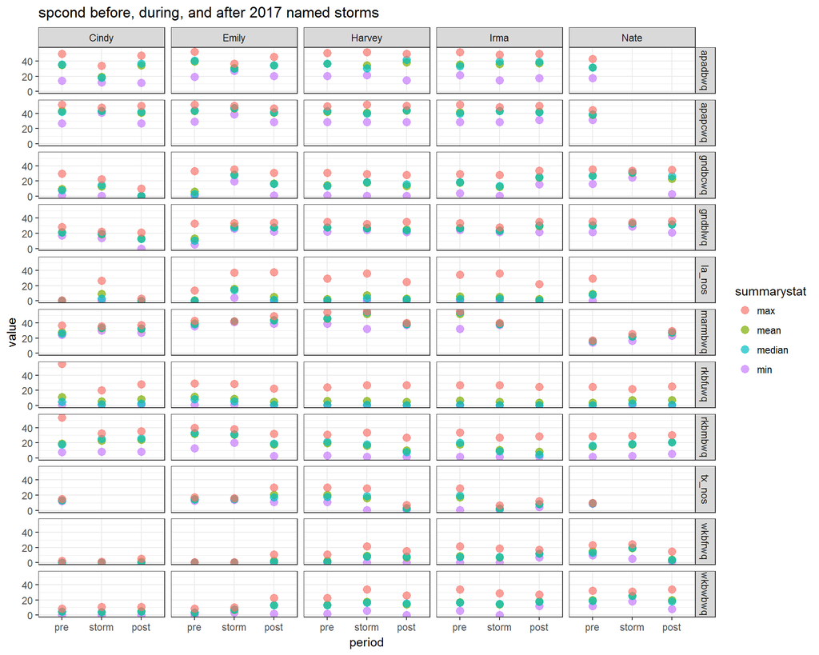

```r
wqparam_grid("spcond")
```

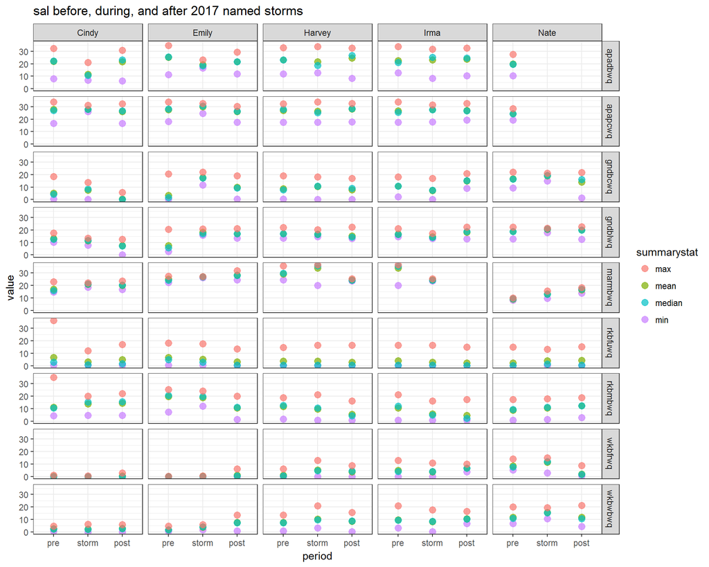

```r
wqparam_grid("sal")
```

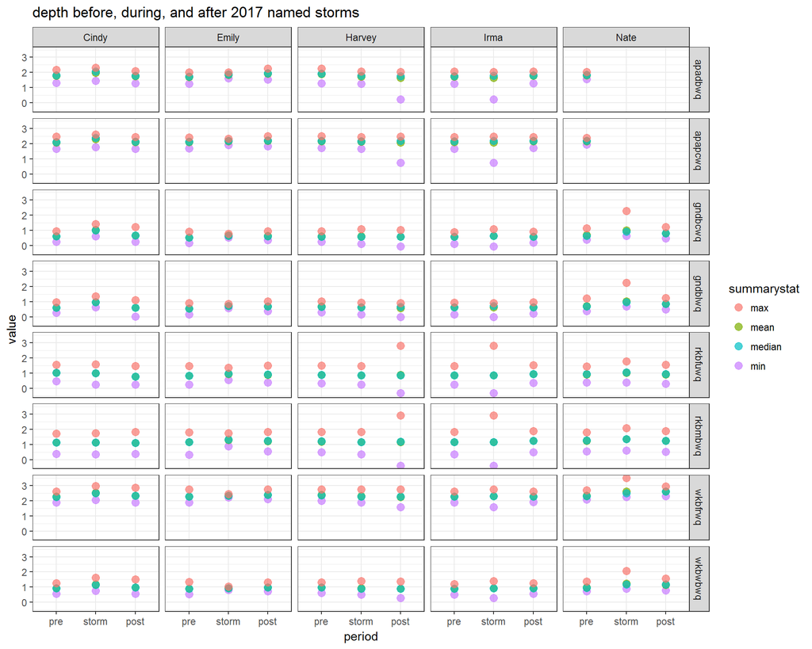

```r
wqparam_grid("depth")
```

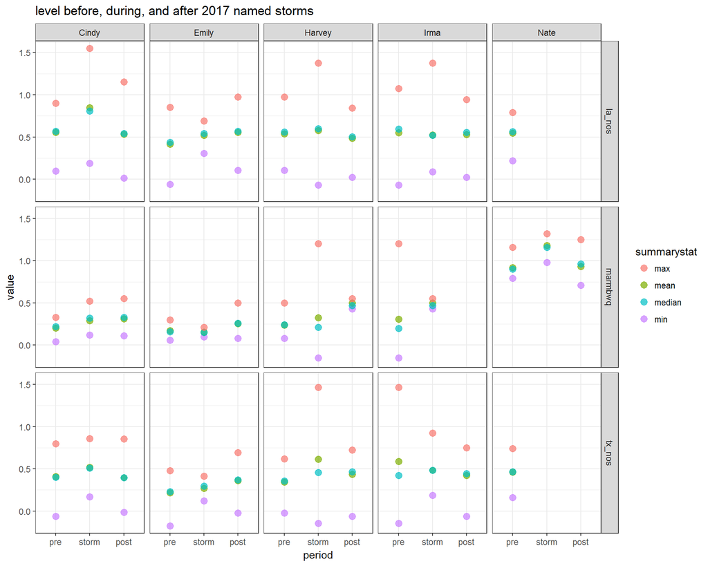

```r
wqparam_grid("level")
```

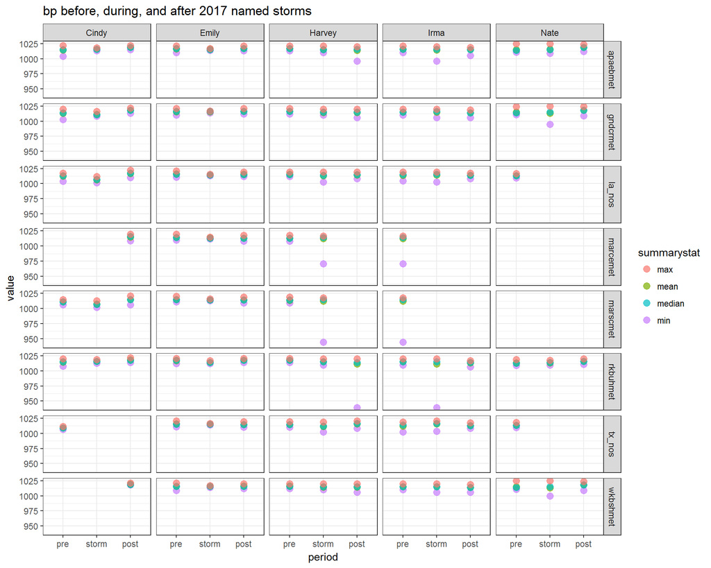

```r
metparam_grid("bp")
```

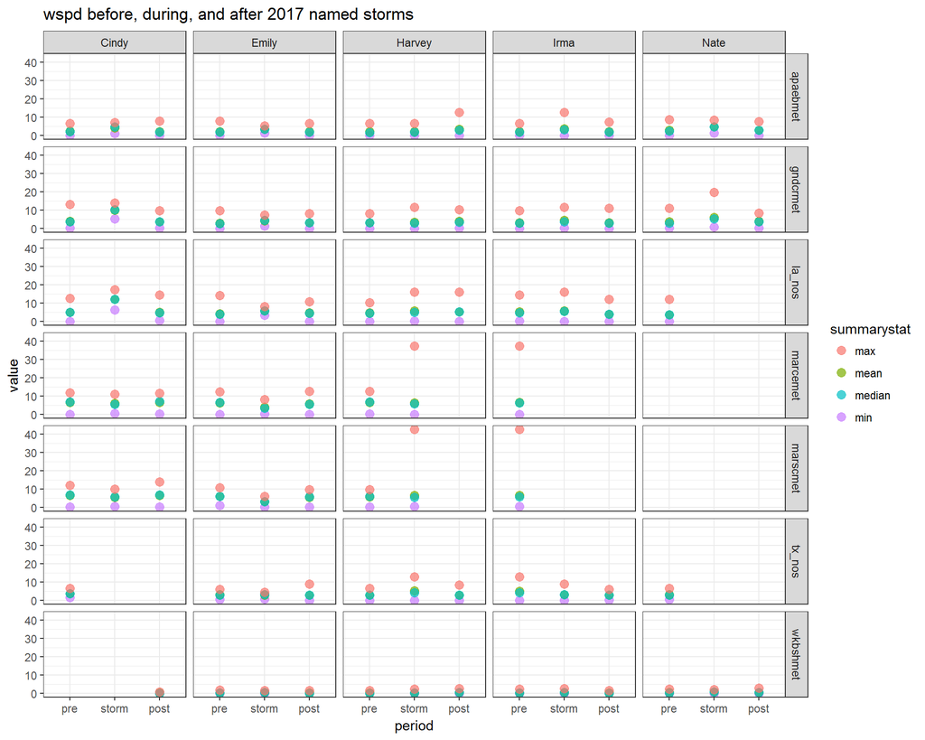

```r
metparam_grid("wspd")
```

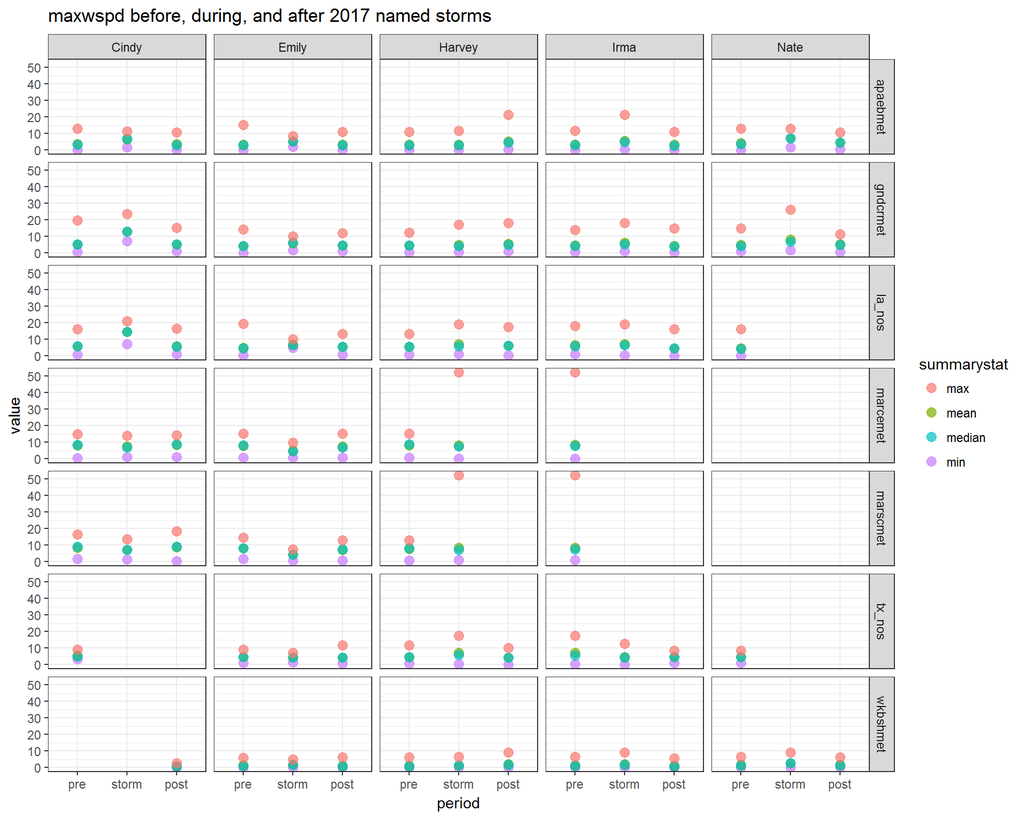

```r
metparam_grid("maxwspd")
```

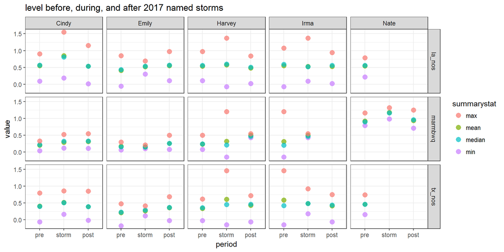

```r
wqparam_grid("level")
```

#### Do that again, but with free y-scales

Make functions (one for wq and one for met) to plot storm x site on a grid, and run them on the various parameters.

```r
wqparam_grid <- function(param_of_interest){

    subdat <- wq_all_long %>%
        filter(measure == param_of_interest)

    ggplot(subdat, aes(x=period, y=value)) +
        geom_point(aes(col=summarystat), size=3, alpha=0.7) +
        facet_grid(stationcode ~ storm_name, scales = "free") +
        theme_bw() +
        ggtitle(paste0(param_of_interest, " before, during, and after 2017 named storms"))
}


metparam_grid <- function(param_of_interest){

    subdat <- met_all_long %>%
        filter(measure == param_of_interest)

    ggplot(subdat, aes(x=period, y=value)) +
        geom_point(aes(col=summarystat), size=3, alpha=0.7) +
        facet_grid(stationcode ~ storm_name, scales="free") +
        theme_bw() +
        ggtitle(paste0(param_of_interest, " before, during, and after 2017 named storms"))
}
```

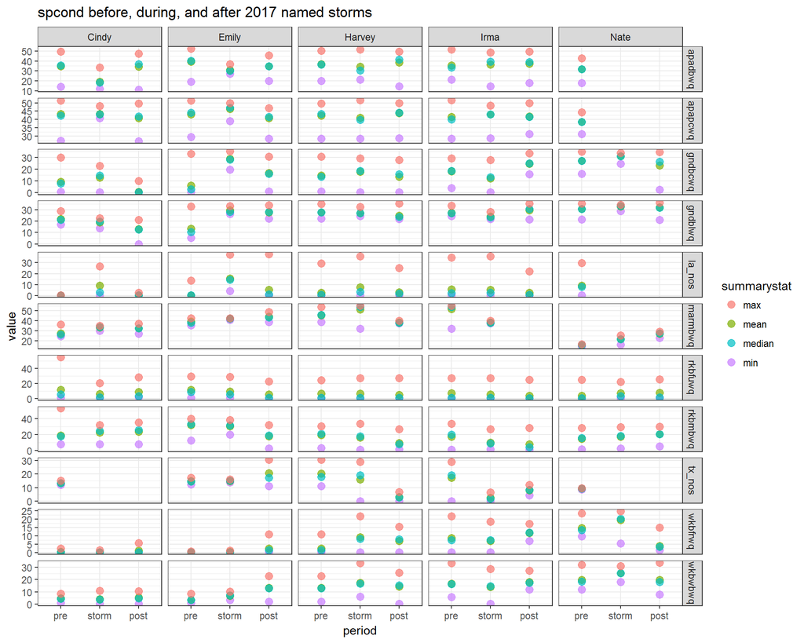

```r
wqparam_grid("spcond")
```

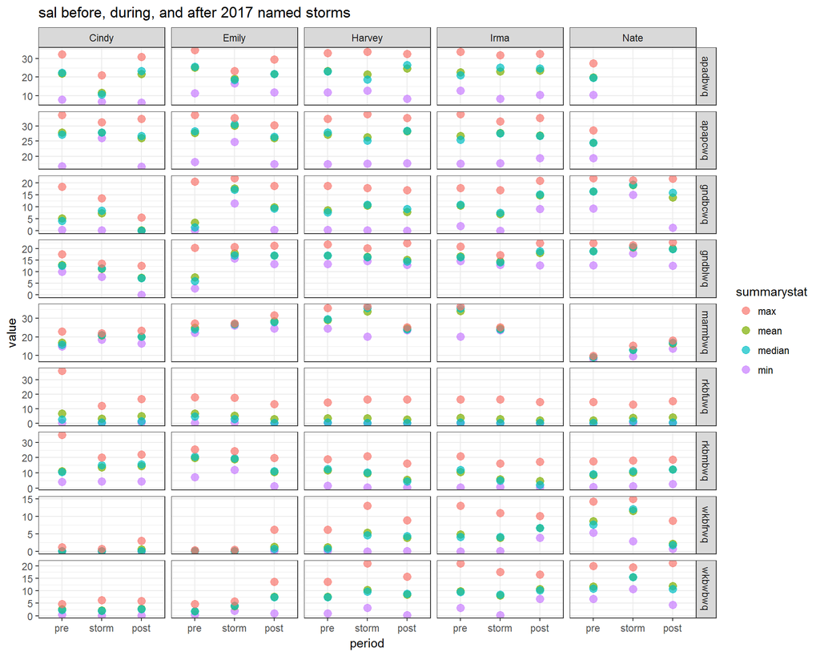

```r
wqparam_grid("sal")
```

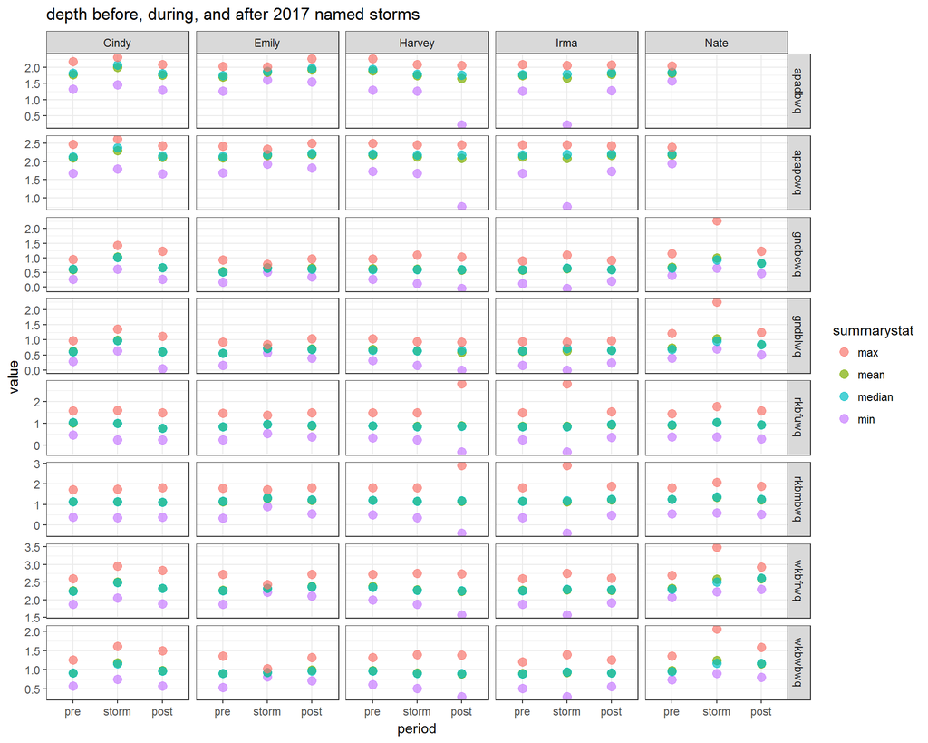

```r
wqparam_grid("depth")
```

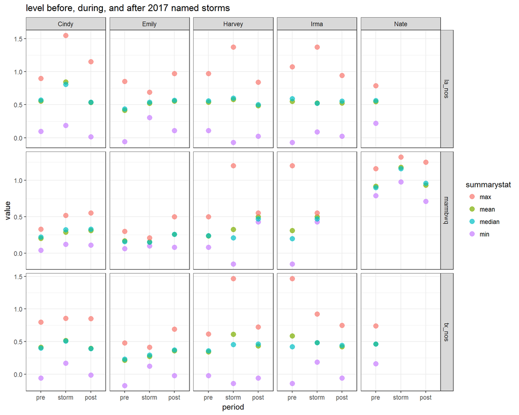

```r
wqparam_grid("level")
```

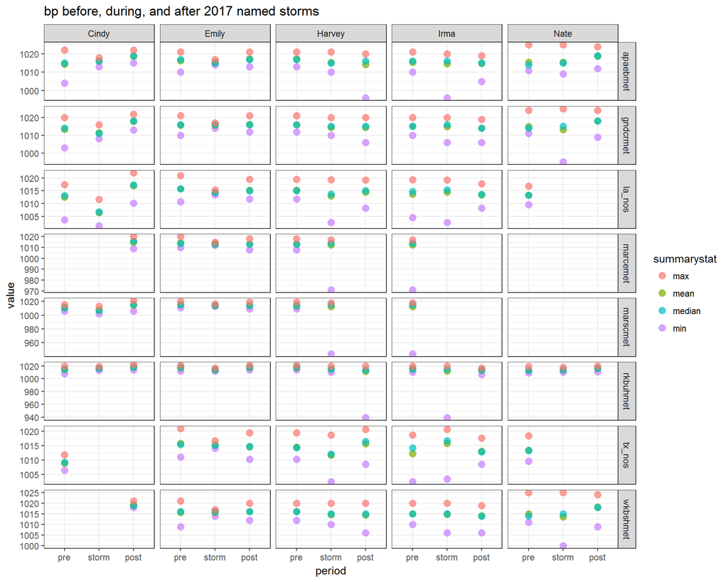

```r
metparam_grid("bp")
```

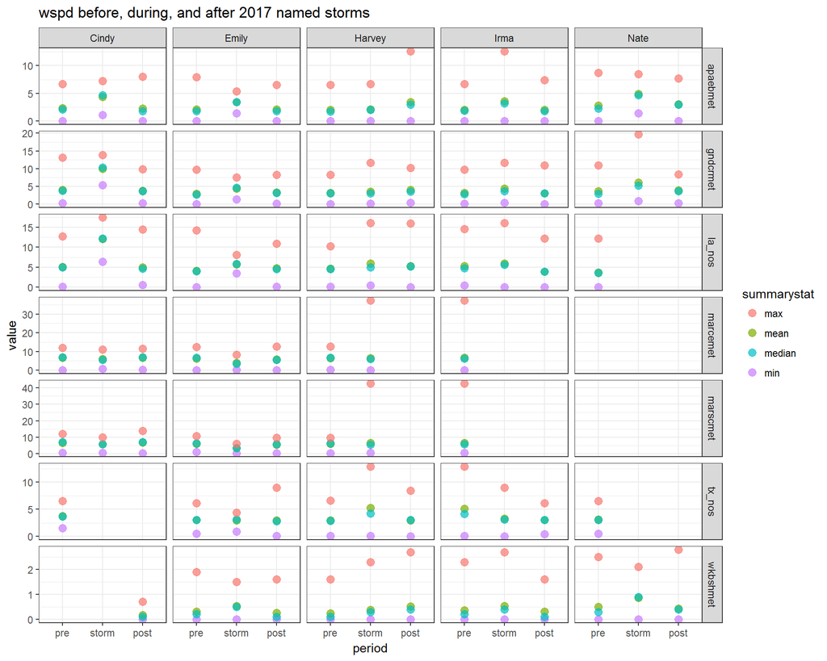

```r
metparam_grid("wspd")
```

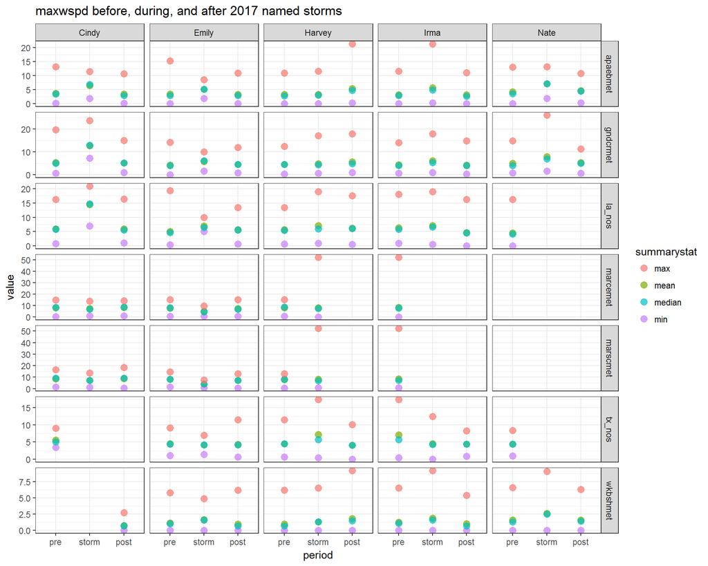

```r
metparam_grid("maxwspd")
```

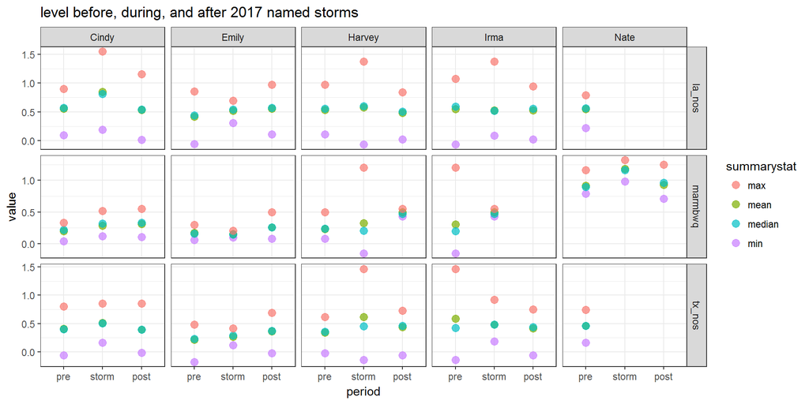

```r
wqparam_grid("level")
```

### Would be nice to have a ribbon plot

So I need to reshape the data again:

```r
wq_all_wide <- wq_all_long %>%
    spread(key = summarystat, value = value)

met_all_wide <- met_all_long %>%
    spread(key = summarystat, value = value)
```

And graph:

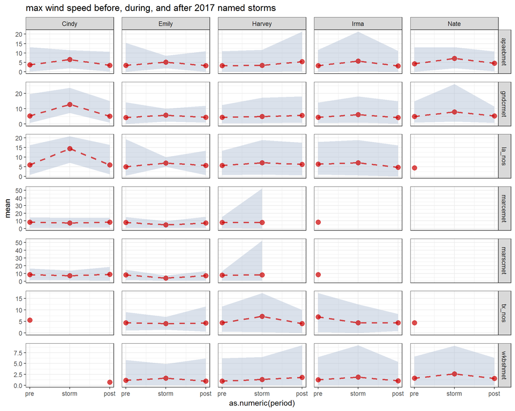

```r
subdat <- met_all_wide %>%
        filter(measure == "maxwspd")

    ggplot(subdat, aes(x=as.numeric(period))) +
        geom_ribbon(aes(ymin=min, ymax=max), fill="lightsteelblue3", alpha=0.4) +
        geom_point(aes(y=mean), size=3, alpha=0.7, col="red3") +
        geom_line(aes(y=mean), alpha=0.7, lty=2, lwd=1, col="red3") +
        facet_grid(stationcode ~ storm_name, scales="free") +
        scale_x_continuous(breaks=c(1:3), labels = levels(subdat$period)) +
        theme_bw() +
        theme(panel.spacing = unit(0.8, "lines")) +
        ggtitle("max wind speed before, during, and after 2017 named storms")
```

### Free y-scales showing data range for each storm period; each param; red is mean

```r
wqribbon_grid <- function(param_of_interest){

    subdat <- wq_all_wide %>%
        filter(measure == param_of_interest)

    ggplot(subdat, aes(x=as.numeric(period))) +
        geom_ribbon(aes(ymin=min, ymax=max), fill="lightsteelblue3", alpha=0.4) +
        geom_point(aes(y=mean), size=3, alpha=0.7, col="red3") +
        geom_line(aes(y=mean), alpha=0.7, lty=2, lwd=1, col="red3") +
        facet_grid(stationcode ~ storm_name, scales="free") +
        scale_x_continuous(breaks=c(1:3), labels = levels(subdat$period)) +
        theme_bw() +
        theme(panel.spacing = unit(0.8, "lines")) +
        ggtitle(paste0(param_of_interest, " before, during, and after 2017 named storms")) +
        xlab("time period") +
        ylab("values")
}


metparam_grid <- function(param_of_interest){

    subdat <- met_all_wide %>%
        filter(measure == param_of_interest)

    ggplot(subdat, aes(x=as.numeric(period))) +
        geom_ribbon(aes(ymin=min, ymax=max), fill="lightsteelblue3", alpha=0.4) +
        geom_point(aes(y=mean), size=3, alpha=0.7, col="red3") +
        geom_line(aes(y=mean), alpha=0.7, lty=2, lwd=1, col="red3") +
        facet_grid(stationcode ~ storm_name, scales="free") +
        scale_x_continuous(breaks=c(1:3), labels = levels(subdat$period)) +
        theme_bw() +
        theme(panel.spacing = unit(0.8, "lines")) +
        ggtitle(paste0(param_of_interest, " before, during, and after 2017 named storms")) +
        xlab("time period") +
        ylab("values")
}
```

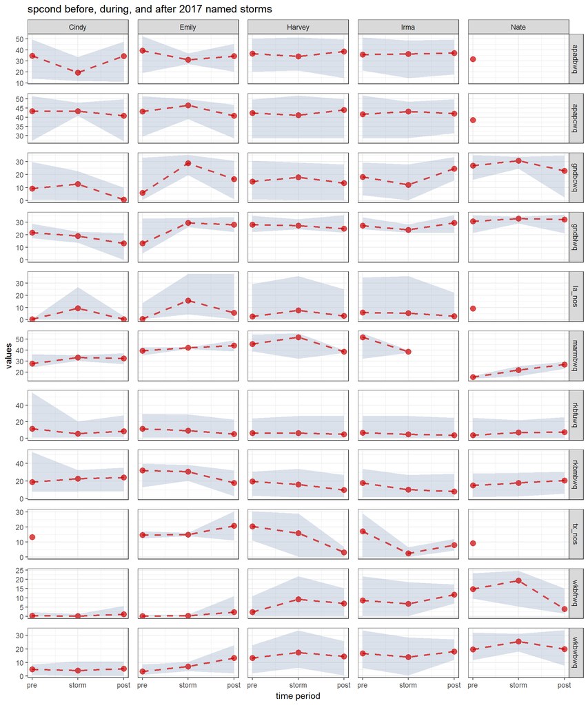

```r
wqribbon_grid("spcond")
```

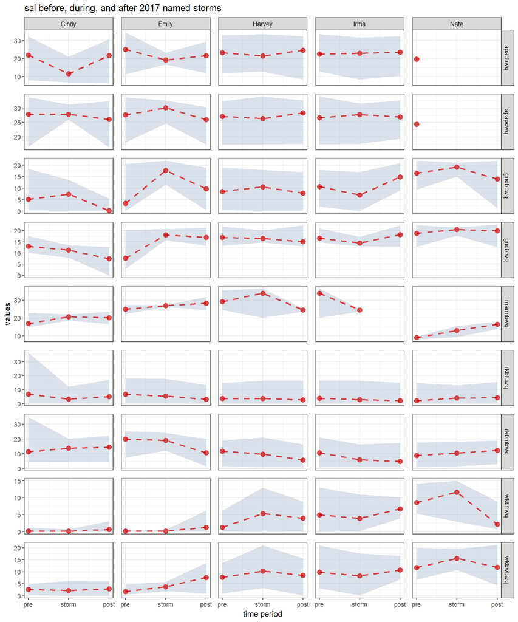

```r
wqribbon_grid("sal")
```

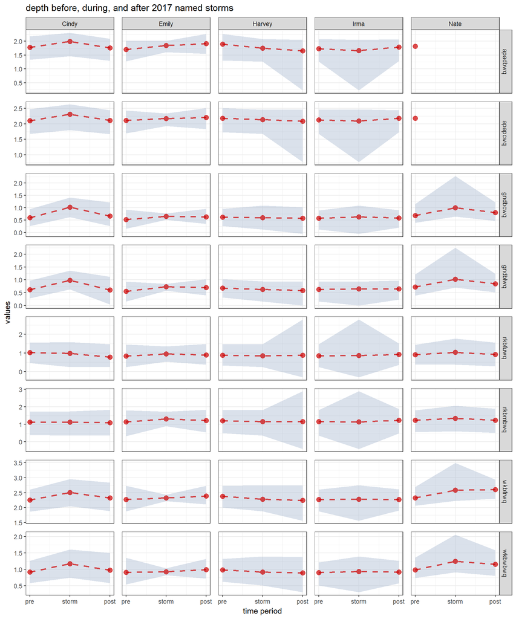

```r
wqribbon_grid("depth")
```